# Flanker MLM Trait Relationships for Publication

PD Inhibition Project

Michael Hallquist

29 May 2020

# Initial model in Mplus (m17)

This model mimics m17 from flanker RT mlms for publication. Here, I start out with a two-level model to keep life simpler, rather than having blocks nested within subjects.

```
m17 <- lmer(rt_inv ~ cond*block + trial_z + prev_rt_z + prev_error +
              (1 + trial_z + prev_rt_z + cond + prev_error | id) +
              (1 + trial_z + run_trial_z + prev_rt_z | id:block),
          na.action = na.exclude, control=lmerControl(optCtrl=list(maxfun=2e4)), #bump up iterations
          data = flanker, REML=FALSE) # control=lmerControl(optimizer = "nlminbwrap"))
```

```r
m17_mplus <- mplusObject(
  TITLE = "Equivalent model to lmer m17",
  DEFINE = "
    cond = cond - 1; ! 0=congruent, 1=incongruent
    block = block - 1; ! 0=most_incon, 1=most_con
    cond_block = cond*block; ! 1=most_con, incongruent
  ",
  VARIABLE = "
    WITHIN = cond block cond_block prev_rt_z prev_error trial_z run_trial_z;
    USEVARIABLES = id rt_inv cond block prev_rt_z
      prev_error trial_z run_trial_z cond_block;
    CLUSTER = id;
  ",
  ANALYSIS = "
    TYPE=TWOLEVEL RANDOM;
    ESTIMATOR=BAYES;
    BITERATIONS=(10000);
    CHAINS=2;
    PROCESSORS=4;
  ",
  MODEL = "
    %WITHIN%
    rt_inv ON block cond_block;
    condslo | rt_inv ON cond;        !random slope of cond
    runslo | rt_inv ON run_trial_z;  !random slope of run_trial
    trialslo | rt_inv ON trial_z;    !random slope of trial
    prevslo | rt_inv ON prev_rt_z;   !random slope of rt autocorrelation
    errslo | rt_inv ON prev_error;   !random slope of previous error

    %BETWEEN%
    !means of random slopes
    [condslo];
    [runslo];
    [trialslo];
    [prevslo];
    [errslo];

    !variances of random slopes
    condslo;
    runslo;
    trialslo;
    prevslo;
    errslo;

    !slope correlations
    condslo runslo trialslo prevslo errslo WITH
       condslo runslo trialslo prevslo errslo;

    [rt_inv]; !mean average inverse RT
  ",
  PLOT = "TYPE = PLOT2;",
  OUTPUT = "TECH1 TECH8 STANDARDIZED CINTERVAL;",
  rdata = flanker
)
```

```
## R variables selected automatically as any variable name that
## occurs in the MODEL, VARIABLE, or DEFINE section.
```

```
## The following variables are not unique in the first 8 characters:
##  run_trial_z
```

```r
mout <- mplusModeler(m17_mplus, dataout="flanker_mplus.dat",
                     modelout="rt_m17.inp", run=TRUE, hashfilename = FALSE,
                     Mplus_command = mpluscmd)
```

```
## When hashfilename = FALSE, writeData cannot be 'ifmissing', setting to 'always'
```

```
## Wrote model to: rt_m17.inp
```

```
## Wrote data to: flanker_mplus.dat
```

```
## Factors will be converted to numbers in Mplus data file
```

```
##
## Factor: cond
## Conversion:
##        level number
##    congruent      1
##  incongruent      2
##
## Factor: block
## Conversion:
##       level number
##  most_incon      1
##    most_con      2
```

```
## The file(s)
##  'flanker_mplus.dat'
## currently exist(s) and will be overwritten
```

```
##
## Running model: rt_m17.inp
## System command: cd "/Users/michael/Data_Analysis/PD_Inhibition_DDM/Code/mlm/flanker" && "/Applications/Mplus/mplus" "rt_m17.inp"
## Reading model:  rt_m17.out
```

```r
summary(mout)
```

```
##  Equivalent model to lmer m17Estimated using BAYES
## Number of obs: 15777, number of (free) parameters: 25
##
## Fit Indices:
##
## CFI = NA, TLI = NA, SRMR = NA
## RMSEA = NA, 90% CI [NA, NA], p < .05 = NA
## AIC = NA, BIC = NA
```

# Consider dropping run_trial since it has little variation and zero mean

Turns out that DIC is 9 points lower for the model that keeps run_trial in the mix.

```r
m17_mplus_noruntrial <- mplusObject(
  TITLE = "Equivalent model to lmer m17, drop run_trial",
  DEFINE = "
    cond = cond - 1; ! 0=congruent, 1=incongruent
    block = block - 1; ! 0=most_incon, 1=most_con
    cond_block = cond*block; ! 1=most_con, incongruent
  ",
  VARIABLE = "
    WITHIN = cond block cond_block prev_rt_z prev_error trial_z;
    USEVARIABLES = id rt_inv cond block prev_rt_z
      prev_error trial_z cond_block;
    CLUSTER = id;
  ",
  ANALYSIS = "
    TYPE=TWOLEVEL RANDOM;
    ESTIMATOR=BAYES;
    BITERATIONS=(10000);
    CHAINS=2;
    PROCESSORS=4;
  ",
  MODEL = "
    %WITHIN%
    rt_inv ON block cond_block;
    condslo | rt_inv ON cond;        !random slope of cond
    trialslo | rt_inv ON trial_z;    !random slope of trial
    prevslo | rt_inv ON prev_rt_z;   !random slope of rt autocorrelation
    errslo | rt_inv ON prev_error;   !random slope of previous error

    %BETWEEN%
    !means of random slopes
    [condslo];
    [trialslo];
    [prevslo];
    [errslo];

    !variances of random slopes
    condslo;
    trialslo;
    prevslo;
    errslo;

    !slope correlations
    condslo trialslo prevslo errslo WITH
       condslo trialslo prevslo errslo;

    [rt_inv]; !mean average inverse RT
  ",
  PLOT = "TYPE = PLOT2;",
  OUTPUT = "TECH1 TECH8 STANDARDIZED CINTERVAL;",
  rdata = flanker
)
```

```
## R variables selected automatically as any variable name that
## occurs in the MODEL, VARIABLE, or DEFINE section.
```

```r
mout <- mplusModeler(m17_mplus_noruntrial, dataout="flanker_mplus.dat",
                     modelout="rt_m17_noruntrial.inp", run=TRUE, hashfilename = FALSE,
                     Mplus_command = mpluscmd)
```

```
## When hashfilename = FALSE, writeData cannot be 'ifmissing', setting to 'always'
```

```
## Wrote model to: rt_m17_noruntrial.inp
```

```
## Wrote data to: flanker_mplus.dat
```

```
## Factors will be converted to numbers in Mplus data file
```

```
##
## Factor: cond
## Conversion:
##        level number
##    congruent      1
##  incongruent      2
##
## Factor: block
## Conversion:
##       level number
##  most_incon      1
##    most_con      2
```

```
## The file(s)
##  'flanker_mplus.dat'
## currently exist(s) and will be overwritten
```

```
##
## Running model: rt_m17_noruntrial.inp
## System command: cd "/Users/michael/Data_Analysis/PD_Inhibition_DDM/Code/mlm/flanker" && "/Applications/Mplus/mplus" "rt_m17_noruntrial.inp"
## Reading model:  rt_m17_noruntrial.out
```

```r
summary(mout)
```

```
##  Equivalent model to lmer m17, drop run_trialEstimated using BAYES
## Number of obs: 15777, number of (free) parameters: 19
##
## Fit Indices:
##
## CFI = NA, TLI = NA, SRMR = NA
## RMSEA = NA, 90% CI [NA, NA], p < .05 = NA
## AIC = NA, BIC = NA
```

# Middle ground, keep run_trial as fixed effect at L1

Still worse

```r
m17_mplus_fixedruntrial <- mplusObject(
  TITLE = "Equivalent model to lmer m17, drop run_trial",
  DEFINE = "
    cond = cond - 1; ! 0=congruent, 1=incongruent
    block = block - 1; ! 0=most_incon, 1=most_con
    cond_block = cond*block; ! 1=most_con, incongruent
  ",
  VARIABLE = "
    WITHIN = cond block cond_block prev_rt_z prev_error trial_z run_trial_z;
    USEVARIABLES = id rt_inv cond block prev_rt_z
      prev_error trial_z run_trial_z cond_block;
    CLUSTER = id;
  ",
  ANALYSIS = "
    TYPE=TWOLEVEL RANDOM;
    ESTIMATOR=BAYES;
    BITERATIONS=(10000);
    CHAINS=2;
    PROCESSORS=4;
  ",
  MODEL = "
    %WITHIN%
    rt_inv ON block cond_block run_trial_z;
    condslo | rt_inv ON cond;        !random slope of cond
    trialslo | rt_inv ON trial_z;    !random slope of trial
    prevslo | rt_inv ON prev_rt_z;   !random slope of rt autocorrelation
    errslo | rt_inv ON prev_error;   !random slope of previous error

    %BETWEEN%
    !means of random slopes
    [condslo];
    [trialslo];
    [prevslo];
    [errslo];

    !variances of random slopes
    condslo;
    trialslo;
    prevslo;
    errslo;

    !slope correlations
    condslo trialslo prevslo errslo WITH
       condslo trialslo prevslo errslo;

    [rt_inv]; !mean average inverse RT
  ",
  PLOT = "TYPE = PLOT2;",
  OUTPUT = "TECH1 TECH8 STANDARDIZED CINTERVAL;",
  rdata = flanker
)
```

```
## R variables selected automatically as any variable name that
## occurs in the MODEL, VARIABLE, or DEFINE section.
```

```
## The following variables are not unique in the first 8 characters:
##  run_trial_z
```

```r
mout <- mplusModeler(m17_mplus_fixedruntrial, dataout="flanker_mplus.dat",
                     modelout="rt_m17_fixedruntrial.inp", run=TRUE, hashfilename = FALSE,
                     Mplus_command = mpluscmd)
```

```
## When hashfilename = FALSE, writeData cannot be 'ifmissing', setting to 'always'
```

```
## Wrote model to: rt_m17_fixedruntrial.inp
```

```
## Wrote data to: flanker_mplus.dat
```

```
## Factors will be converted to numbers in Mplus data file
```

```
##
## Factor: cond
## Conversion:
##        level number
##    congruent      1
##  incongruent      2
##
## Factor: block
## Conversion:
##       level number
##  most_incon      1
##    most_con      2
```

```
## The file(s)
##  'flanker_mplus.dat'
## currently exist(s) and will be overwritten
```

```
##
## Running model: rt_m17_fixedruntrial.inp
## System command: cd "/Users/michael/Data_Analysis/PD_Inhibition_DDM/Code/mlm/flanker" && "/Applications/Mplus/mplus" "rt_m17_fixedruntrial.inp"
## Reading model:  rt_m17_fixedruntrial.out
```

```r
results <- mout$results
```

# Prune a few tiny runslo covariances in the between model

Tried to prune runslo relationship with trialslo and condslo. This throws the dreaded:

```
*** FATAL ERROR
     THE VARIANCE COVARIANCE MATRIX IS NOT SUPPORTED.
     ONLY FULL VARIANCE COVARIANCE BLOCKS ARE ALLOWED.
     USE ALGORITHM=GIBBS(RW) OR ALGORITHM=MH TO RESOLVE THIS PROBLEM.
```

Thus, stick with full m17 above.

# Antagonism MSEM

Replicate parceling approach from Trait_Structure RMD file.

Here are the couplets:

1. MISTRUST (Mistrustfulness) and MPS_alr (Alienation)
2. PROPER (Propriety) and MPS_tdr (Traditionalism)
3. IMPUL (Impulsivity, reversed) and MPS_clr (Control)
4. HDWK (Hard-working) and MPS_acr (Achievement)
5. AGG (Aggression) and MPS_agr (Aggression)

```r
tofactor <- self_reps %>% select(subject, MPS_agR, AGG, MISTRUST, MPS_alR, MANIP,
      PROPER, MPS_clR, IMPUL, MPS_tdR, MPS_acR, HDWK, K10, STAI) %>%
  mutate(IMPUL =-1*IMPUL) %>% #score toward constraint to make loadings upright
  mutate_at(vars(-subject), list(~as.vector(scale(.)))) %>%
  dplyr::rename(id=subject)

for_msem <- flanker %>% inner_join(tofactor, by="id")
anti_join(tofactor, flanker, by="id")
```

```
##   id MPS_agR    AGG MISTRUST MPS_alR  MANIP PROPER MPS_clR  IMPUL MPS_tdR MPS_acR   HDWK     K10   STAI
## 1 44  -0.163 -0.314   -1.333  -0.683 -0.363 -1.701  -0.562 -0.846 -0.3274  -0.355 -0.401 -1.2583 -0.708
## 2 47   0.542  0.961    0.237  -0.683  0.172  0.191  -0.562 -0.316  0.8605  -0.355 -0.648  0.0616  0.805
## 3 55   0.190 -0.314    1.359  -0.305 -0.363 -0.282  -1.651 -0.581  0.0685   0.609  0.339  0.0616 -0.613
## 4 83  -1.220 -1.079   -1.108  -1.060 -1.433  0.900   0.890  1.274  1.2565  -0.034 -0.401 -1.8240 -0.992
```

Note that the four IDs excluded from flanker all have valid self-report data. But 7 good flanker subjects have bad self-report data, I think. Thus, we move to a sample of 100 total for the combined analysis.

ID 44 appears to be missing flanker data altogether (even in original excel file)

```r
length(unique(for_msem$id))
```

```
## [1] 100
```

```r
AC_msem <- mplusObject(
  TITLE="Antagonism and Constraint BSEM CFA 3+3 Parcels, Flanker RT",
  DEFINE="
    p1=MEAN(MISTRUST MPS_alR);
    p2=MEAN(PROPER MPS_tdR);
    p3=MEAN(MPS_clR IMPUL);
    p4=MEAN(MPS_acR HDWK);
    p5=MEAN(MPS_agR AGG);
    cond = cond - 1; ! 0=congruent, 1=incongruent
    block = block - 1; ! 0=most_incon, 1=most_con
    cond_block = cond*block; ! 1=most_con, incongruent
  ",

  VARIABLE = "
    WITHIN = cond block cond_block prev_rt_z prev_error trial_z run_trial_z;
    USEVARIABLES = id rt_inv cond block prev_rt_z
      prev_error trial_z run_trial_z
      MANIP p1 p2 p3 p4 p5 cond_block;
    BETWEEN = MANIP p1 p2 p3 p4 p5;
    CLUSTER = id;
  ",
  ANALYSIS = "
    TYPE=TWOLEVEL RANDOM;
    ESTIMATOR=BAYES;
    BITERATIONS=(15000);
    CHAINS=4;
    PROCESSORS=4;
  ",
  MODEL = "

  %WITHIN%
    rt_inv ON block cond_block;
    condslo | rt_inv ON cond;        !random slope of cond
    prevslo | rt_inv ON prev_rt_z;   !random slope of rt autocorrelation
    errslo | rt_inv ON prev_error;   !random slope of previous error
    runslo | rt_inv ON run_trial_z;  !random slope of run_trial
    trialslo | rt_inv ON trial_z;    !random slope of trial

  %BETWEEN%
    !means of random slopes
    [condslo];
    [runslo];
    [trialslo];
    [prevslo];
    [errslo];

    !variances of random slopes
    condslo;
    runslo;
    trialslo;
    prevslo;
    errslo;

    !slope correlations
    condslo runslo trialslo prevslo errslo WITH
       condslo runslo trialslo prevslo errslo;

    [rt_inv]; !mean average inverse RT

    !TRAIT MODEL

    antag BY p5* ! MPS_agR AGG
      p1        ! MISTRUST MPS_alR
      MANIP;
    antag@1;

    constraint BY
      p2*  !PROPER MPS_tdR
      p3  !MPS_clR IMPUL
      p4; !MPS_acR HDWK;
    constraint@1;

    antag WITH constraint;

    !TRAIT MODERATION

    ! trait moderates flanker performance
    condslo ON antag constraint;
    prevslo ON antag constraint;
    errslo ON antag constraint;

    !N.B. Leaving out the association of antag with rt_inv
    !omits a hugely important relationship.
    !Thus, allow antag as a predictor of average (person) RT
    rt_inv ON antag constraint;
  ",
  PLOT = "TYPE = PLOT2;",
  OUTPUT ="
    TECH1 TECH8 STANDARDIZED CINTERVAL;
  ",
  rdata=for_msem
)
```

```
## R variables selected automatically as any variable name that
## occurs in the MODEL, VARIABLE, or DEFINE section.
```

```
## The following variables are not unique in the first 8 characters:
##  run_trial_z, prev_rt_z
```

```r
mres <- mplusModeler(AC_msem, modelout = file.path("rt_m17_AC.inp"),
                     run=TRUE, hashfilename = FALSE,
                     Mplus_command = mpluscmd)
```

```
## When hashfilename = FALSE, writeData cannot be 'ifmissing', setting to 'always'
```

```
## Wrote model to: rt_m17_AC.inp
```

```
## Wrote data to: rt_m17_AC.dat
```

```
## Factors will be converted to numbers in Mplus data file
```

```
##
## Factor: cond
## Conversion:
##        level number
##    congruent      1
##  incongruent      2
##
## Factor: block
## Conversion:
##       level number
##  most_incon      1
##    most_con      2
```

```
## The file(s)
##  'rt_m17_AC.dat'
## currently exist(s) and will be overwritten
```

```
##
## Running model: rt_m17_AC.inp
## System command: cd "/Users/michael/Data_Analysis/PD_Inhibition_DDM/Code/mlm/flanker" && "/Applications/Mplus/mplus" "rt_m17_AC.inp"
## Reading model:  rt_m17_AC.out
```

```r
summary(mres)
```

```
##  Antagonism and Constraint BSEM CFA 3+3 Parcels, Flanker RTEstimated using BAYES
## Number of obs: 15504, number of (free) parameters: 52
##
## Fit Indices:
##
## CFI = NA, TLI = NA, SRMR = NA
## RMSEA = NA, 90% CI [NA, NA], p < .05 = NA
## AIC = NA, BIC = NA
```

```r
kable(mres$results$parameters$stdyx.standardized %>%
        filter(!paramHeader %in% c("Intercepts", "Means", "Residual Variances")))
```

| paramHeader | param | est | posterior_sd | pval | lower_2.5ci | upper_2.5ci | sig | BetweenWithin |
| --- | --- | --- | --- | --- | --- | --- | --- | --- |
| CONDSLO\|RT_INV.ON | COND | 0.159 | 0.012 | 0.000 | 0.135 | 0.182 | TRUE | Within.Std.Averaged.Over.Clusters |
| PREVSLO\|RT_INV.ON | PREV_RT_Z | 0.253 | 0.007 | 0.000 | 0.238 | 0.267 | TRUE | Within.Std.Averaged.Over.Clusters |
| ERRSLO\|RT_INV.ON | PREV_ERROR | 0.085 | 0.007 | 0.000 | 0.072 | 0.098 | TRUE | Within.Std.Averaged.Over.Clusters |
| RUNSLO\|RT_INV.ON | RUN_TRIAL_ | -0.008 | 0.008 | 0.155 | -0.023 | 0.007 | FALSE | Within.Std.Averaged.Over.Clusters |
| TRIALSLO\|RT_INV.ON | TRIAL_Z | -0.043 | 0.008 | 0.000 | -0.058 | -0.028 | TRUE | Within.Std.Averaged.Over.Clusters |
| RT_INV.ON | BLOCK | 0.032 | 0.012 | 0.004 | 0.009 | 0.056 | TRUE | Within.Std.Averaged.Over.Clusters |
| RT_INV.ON | COND_BLOCK | 0.047 | 0.012 | 0.000 | 0.024 | 0.070 | TRUE | Within.Std.Averaged.Over.Clusters |
| Residual.Variances | RT_INV | 0.831 | 0.005 | 0.000 | 0.821 | 0.841 | TRUE | Within.Std.Averaged.Over.Clusters |
| ANTAG.BY | P5 | 0.744 | 0.072 | 0.000 | 0.586 | 0.867 | TRUE | Between |
| ANTAG.BY | P1 | 0.632 | 0.086 | 0.000 | 0.442 | 0.779 | TRUE | Between |
| ANTAG.BY | MANIP | 0.814 | 0.069 | 0.000 | 0.657 | 0.925 | TRUE | Between |
| CONSTRAI.BY | P2 | 0.763 | 0.113 | 0.000 | 0.516 | 0.952 | TRUE | Between |
| CONSTRAI.BY | P3 | 0.578 | 0.111 | 0.000 | 0.354 | 0.787 | TRUE | Between |
| CONSTRAI.BY | P4 | 0.487 | 0.109 | 0.000 | 0.261 | 0.684 | TRUE | Between |
| CONDSLO.ON | ANTAG | 0.445 | 0.137 | 0.001 | 0.153 | 0.688 | TRUE | Between |
| CONDSLO.ON | CONSTRAINT | -0.066 | 0.160 | 0.341 | -0.362 | 0.262 | FALSE | Between |
| PREVSLO.ON | ANTAG | -0.034 | 0.147 | 0.410 | -0.325 | 0.252 | FALSE | Between |
| PREVSLO.ON | CONSTRAINT | -0.359 | 0.151 | 0.015 | -0.630 | -0.040 | TRUE | Between |
| ERRSLO.ON | ANTAG | -0.050 | 0.160 | 0.379 | -0.358 | 0.267 | FALSE | Between |
| ERRSLO.ON | CONSTRAINT | -0.045 | 0.177 | 0.404 | -0.385 | 0.304 | FALSE | Between |
| RT_INV.ON | ANTAG | -0.287 | 0.115 | 0.009 | -0.498 | -0.048 | TRUE | Between |
| RT_INV.ON | CONSTRAINT | 0.078 | 0.129 | 0.275 | -0.185 | 0.320 | FALSE | Between |
| CONDSLO.WITH | RUNSLO | -0.055 | 0.189 | 0.388 | -0.416 | 0.316 | FALSE | Between |
| CONDSLO.WITH | TRIALSLO | -0.360 | 0.160 | 0.018 | -0.648 | -0.022 | TRUE | Between |
| CONDSLO.WITH | PREVSLO | -0.166 | 0.202 | 0.213 | -0.550 | 0.233 | FALSE | Between |
| CONDSLO.WITH | ERRSLO | -0.274 | 0.223 | 0.121 | -0.683 | 0.188 | FALSE | Between |
| RUNSLO.WITH | TRIALSLO | 0.041 | 0.165 | 0.404 | -0.277 | 0.360 | FALSE | Between |
| RUNSLO.WITH | PREVSLO | -0.120 | 0.177 | 0.259 | -0.454 | 0.237 | FALSE | Between |
| RUNSLO.WITH | ERRSLO | -0.122 | 0.188 | 0.268 | -0.476 | 0.255 | FALSE | Between |
| TRIALSLO.WITH | PREVSLO | -0.014 | 0.157 | 0.465 | -0.316 | 0.295 | FALSE | Between |
| TRIALSLO.WITH | ERRSLO | 0.107 | 0.176 | 0.275 | -0.237 | 0.446 | FALSE | Between |
| PREVSLO.WITH | ERRSLO | 0.397 | 0.198 | 0.034 | -0.031 | 0.736 | FALSE | Between |
| ANTAG.WITH | CONSTRAINT | -0.164 | 0.146 | 0.132 | -0.445 | 0.125 | FALSE | Between |
| Variances | ANTAG | 1.000 | 0.000 | 0.000 | 1.000 | 1.000 | FALSE | Between |
| Variances | CONSTRAINT | 1.000 | 0.000 | 0.000 | 1.000 | 1.000 | FALSE | Between |
| Variances | RUNSLO | 1.000 | 0.000 | 0.000 | 1.000 | 1.000 | FALSE | Between |
| Variances | TRIALSLO | 1.000 | 0.000 | 0.000 | 1.000 | 1.000 | FALSE | Between |
| Residual.Variances | MANIP | 0.337 | 0.109 | 0.000 | 0.144 | 0.569 | TRUE | Between |
| Residual.Variances | P1 | 0.601 | 0.105 | 0.000 | 0.393 | 0.804 | TRUE | Between |
| Residual.Variances | P2 | 0.418 | 0.166 | 0.000 | 0.094 | 0.733 | TRUE | Between |
| Residual.Variances | P3 | 0.665 | 0.127 | 0.000 | 0.381 | 0.874 | TRUE | Between |
| Residual.Variances | P4 | 0.763 | 0.105 | 0.000 | 0.532 | 0.932 | TRUE | Between |
| Residual.Variances | P5 | 0.447 | 0.104 | 0.000 | 0.247 | 0.657 | TRUE | Between |
| Residual.Variances | RT_INV | 0.890 | 0.068 | 0.000 | 0.725 | 0.985 | TRUE | Between |
| Residual.Variances | CONDSLO | 0.765 | 0.117 | 0.000 | 0.506 | 0.954 | TRUE | Between |
| Residual.Variances | PREVSLO | 0.855 | 0.104 | 0.000 | 0.597 | 0.987 | TRUE | Between |
| Residual.Variances | ERRSLO | 0.959 | 0.055 | 0.000 | 0.800 | 0.998 | TRUE | Between |

# AC MSEM with cross-loading

Between-persons CFA suggests that P1 cross-loads on constraint. Including this cross-loading makes the fit good enough IMO, while without it, CFI is < .9. Do our effects here hold if we allow that?

```r
AC_msem_mod <- mplusObject(
  TITLE="Antagonism and Constraint BSEM CFA 3+3 Parcels, Flanker RT Mod",
  DEFINE="
    p1=MEAN(MISTRUST MPS_alR);
    p2=MEAN(PROPER MPS_tdR);
    p3=MEAN(MPS_clR IMPUL);
    p4=MEAN(MPS_acR HDWK);
    p5=MEAN(MPS_agR AGG);
    cond = cond - 1; ! 0=congruent, 1=incongruent
    block = block - 1; ! 0=most_incon, 1=most_con
    cond_block = cond*block; ! 1=most_con, incongruent
  ",

  VARIABLE = "
    WITHIN = cond block cond_block prev_rt_z prev_error trial_z run_trial_z;
    USEVARIABLES = id rt_inv cond block prev_rt_z
      prev_error trial_z run_trial_z
      MANIP p1 p2 p3 p4 p5 cond_block;
    BETWEEN = MANIP p1 p2 p3 p4 p5;
    CLUSTER = id;
  ",
  ANALYSIS = "
    TYPE=TWOLEVEL RANDOM;
    ESTIMATOR=BAYES;
    BITERATIONS=(15000);
    CHAINS=2;
    PROCESSORS=4;
  ",
  MODEL = "

  %WITHIN%
    rt_inv ON block (b_block)
      cond_block (b_cxb);
    condslo | rt_inv ON cond;        !random slope of cond
    prevslo | rt_inv ON prev_rt_z;   !random slope of rt autocorrelation
    errslo | rt_inv ON prev_error;   !random slope of previous error
    runslo | rt_inv ON run_trial_z;  !random slope of run_trial
    trialslo | rt_inv ON trial_z;    !random slope of trial


  %BETWEEN%
    !means of random slopes
    [condslo] (c_b0);
    [runslo];
    [trialslo];
    [prevslo] (p_b0);
    [errslo] (e_b0);

    !variances of random slopes
    condslo;
    runslo;
    trialslo;
    prevslo;
    errslo;

    !slope correlations
    condslo runslo trialslo prevslo errslo WITH
       condslo runslo trialslo prevslo errslo;

    [rt_inv] (b0); !mean average inverse RT

    !TRAIT MODEL

    antag BY p5* ! MPS_agR AGG
      p1        ! MISTRUST MPS_alR
      MANIP;
    antag@1;

    constraint BY
      p2*  !PROPER MPS_tdR
      p3  !MPS_clR IMPUL
      p4; !MPS_acR HDWK;
    constraint@1;

    antag WITH constraint;

    constraint BY P1; !modification index cross-loading for fit

    !TRAIT MODERATION

    ! trait moderates flanker performance
    condslo ON antag (c_bA)
      constraint (c_bC);

    prevslo ON antag (p_bA)
      constraint (p_bC);

    errslo ON antag (e_bA)
      constraint (e_bC);

    !N.B. Leaving out the association of antag with rt_inv
    !omits a hugely important relationship.
    !Thus, allow antag as a predictor of average (person) RT
    rt_inv ON antag (bA)
      constraint (bC);
  ",
  MODELCONSTRAINT = "
    NEW (RT_I_loA RT_I_miA RT_I_hiA
         RT_I_loC RT_I_miC RT_I_hiC
         RT_C_loA RT_C_miA RT_C_hiA
         RT_C_loC RT_C_miC RT_C_hiC
         tLo tMi tHi
      );

    tLo = -1;
    tMi = 0;
    tHi = 1;

    !since trial_z and prev_rt_z are mean centered, they
    !drop out of the predicted values (marginalized out)
    !these are predicted values at prev_error = 0, which is more
    !representative anyhow (only 3% errors)
    !Use block = 0.5 to compute the average across blocks

    !pred RT for incongruent trials (cond=1), low Antag
    RT_I_loA = b0 + c_b0 + bA*tLo + c_bA*tLo + 0.5*b_block + 0.5*b_cxb;
    RT_I_miA = b0 + c_b0 + bA*tMi + c_bA*tMi + 0.5*b_block + 0.5*b_cxb;
    RT_I_hiA = b0 + c_b0 + bA*tHi + c_bA*tHi + 0.5*b_block + 0.5*b_cxb;

    !pred RT for congruent trials (cond=0), low Antag
    RT_C_loA = b0 + bA*tLo + 0.5*b_block;
    RT_C_miA = b0 + bA*tMi + 0.5*b_block;
    RT_C_hiA = b0 + bA*tHi + 0.5*b_block;

    !pred RT for incongruent trials (cond=1), low Constraint
    RT_I_loC = b0 + c_b0 + bC*tLo + c_bC*tLo + 0.5*b_block + 0.5*b_cxb;
    RT_I_miC = b0 + c_b0 + bC*tMi + c_bC*tMi + 0.5*b_block + 0.5*b_cxb;
    RT_I_hiC = b0 + c_b0 + bC*tHi + c_bC*tHi + 0.5*b_block + 0.5*b_cxb;

    !pred RT for congruent trials (cond=0), low Antag
    RT_C_loC = b0 + bC*tLo + 0.5*b_block;
    RT_C_miC = b0 + bC*tMi + 0.5*b_block;
    RT_C_hiC = b0 + bC*tHi + 0.5*b_block;
  ",
  PLOT = "TYPE = PLOT2;",
  OUTPUT ="
    TECH1 TECH8 STANDARDIZED CINTERVAL;
  ",
  rdata=for_msem
)
```

```
## R variables selected automatically as any variable name that
## occurs in the MODEL, VARIABLE, or DEFINE section.
```

```
## The following variables are not unique in the first 8 characters:
##  run_trial_z, prev_rt_z
```

```r
mres <- mplusModeler(AC_msem_mod, modelout = file.path("rt_m17_AC_mod.inp"),
                     run=TRUE, hashfilename = FALSE,
                     Mplus_command = mpluscmd)
```

```
## When hashfilename = FALSE, writeData cannot be 'ifmissing', setting to 'always'
```

```
## Wrote model to: rt_m17_AC_mod.inp
```

```
## Wrote data to: rt_m17_AC_mod.dat
```

```
## Factors will be converted to numbers in Mplus data file
```

```
##
## Factor: cond
## Conversion:
##        level number
##    congruent      1
##  incongruent      2
##
## Factor: block
## Conversion:
##       level number
##  most_incon      1
##    most_con      2
```

```
## The file(s)
##  'rt_m17_AC_mod.dat'
## currently exist(s) and will be overwritten
```

```
##
## Running model: rt_m17_AC_mod.inp
## System command: cd "/Users/mnh5174/Data_Analysis/PD_Inhibition_DDM/Code/mlm/flanker" && "/Users/mnh5174/Applications/Mplus/mplus" "rt_m17_AC_mod.inp"
## Reading model:  rt_m17_AC_mod.out
```

```r
summary(mres)
```

```
##  Antagonism and Constraint BSEM CFA 3+3 Parcels, Flanker RT ModEstimated using BAYES
## Number of obs: 15504, number of (free) parameters: 53
##
## Fit Indices:
##
## CFI = NA, TLI = NA, SRMR = NA
## RMSEA = NA, 90% CI [NA, NA], p < .05 = NA
## AIC = NA, BIC = NA
```

```r
kable(mres$results$parameters$stdyx.standardized %>%
        filter(!paramHeader %in% c("Intercepts", "Means", "Residual Variances")))
```

| paramHeader | param | est | posterior_sd | pval | lower_2.5ci | upper_2.5ci | sig | BetweenWithin |
| --- | --- | --- | --- | --- | --- | --- | --- | --- |
| CONDSLO\|RT_INV.ON | COND | 0.159 | 0.012 | 0.000 | 0.135 | 0.181 | TRUE | Within.Std.Averaged.Over.Clusters |
| PREVSLO\|RT_INV.ON | PREV_RT_Z | 0.253 | 0.007 | 0.000 | 0.238 | 0.267 | TRUE | Within.Std.Averaged.Over.Clusters |
| ERRSLO\|RT_INV.ON | PREV_ERROR | 0.085 | 0.006 | 0.000 | 0.072 | 0.097 | TRUE | Within.Std.Averaged.Over.Clusters |
| RUNSLO\|RT_INV.ON | RUN_TRIAL_ | -0.008 | 0.008 | 0.146 | -0.023 | 0.007 | FALSE | Within.Std.Averaged.Over.Clusters |
| TRIALSLO\|RT_INV.ON | TRIAL_Z | -0.043 | 0.008 | 0.000 | -0.058 | -0.028 | TRUE | Within.Std.Averaged.Over.Clusters |
| RT_INV.ON | BLOCK | 0.032 | 0.012 | 0.001 | 0.009 | 0.055 | TRUE | Within.Std.Averaged.Over.Clusters |
| RT_INV.ON | COND_BLOCK | 0.047 | 0.012 | 0.000 | 0.024 | 0.070 | TRUE | Within.Std.Averaged.Over.Clusters |
| Residual.Variances | RT_INV | 0.831 | 0.005 | 0.000 | 0.821 | 0.841 | TRUE | Within.Std.Averaged.Over.Clusters |
| ANTAG.BY | P5 | 0.754 | 0.068 | 0.000 | 0.599 | 0.865 | TRUE | Between |
| ANTAG.BY | P1 | 0.732 | 0.102 | 0.000 | 0.541 | 0.945 | TRUE | Between |
| ANTAG.BY | MANIP | 0.788 | 0.068 | 0.000 | 0.633 | 0.897 | TRUE | Between |
| CONSTRAI.BY | P2 | 0.692 | 0.108 | 0.000 | 0.457 | 0.881 | TRUE | Between |
| CONSTRAI.BY | P3 | 0.616 | 0.104 | 0.000 | 0.390 | 0.802 | TRUE | Between |
| CONSTRAI.BY | P4 | 0.537 | 0.110 | 0.000 | 0.304 | 0.734 | TRUE | Between |
| CONSTRAI.BY | P1 | 0.328 | 0.132 | 0.003 | 0.087 | 0.610 | TRUE | Between |
| CONDSLO.ON | ANTAG | 0.483 | 0.137 | 0.001 | 0.193 | 0.727 | TRUE | Between |
| CONDSLO.ON | CONSTRAINT | 0.060 | 0.174 | 0.366 | -0.266 | 0.412 | FALSE | Between |
| PREVSLO.ON | ANTAG | -0.025 | 0.152 | 0.436 | -0.317 | 0.275 | FALSE | Between |
| PREVSLO.ON | CONSTRAINT | -0.326 | 0.161 | 0.031 | -0.613 | 0.018 | FALSE | Between |
| ERRSLO.ON | ANTAG | -0.063 | 0.165 | 0.355 | -0.380 | 0.261 | FALSE | Between |
| ERRSLO.ON | CONSTRAINT | -0.070 | 0.179 | 0.353 | -0.418 | 0.278 | FALSE | Between |
| RT_INV.ON | ANTAG | -0.312 | 0.119 | 0.007 | -0.527 | -0.065 | TRUE | Between |
| RT_INV.ON | CONSTRAINT | -0.005 | 0.141 | 0.487 | -0.285 | 0.266 | FALSE | Between |
| CONDSLO.WITH | RUNSLO | -0.052 | 0.189 | 0.395 | -0.424 | 0.310 | FALSE | Between |
| CONDSLO.WITH | TRIALSLO | -0.362 | 0.159 | 0.019 | -0.642 | -0.023 | TRUE | Between |
| CONDSLO.WITH | PREVSLO | -0.154 | 0.198 | 0.226 | -0.532 | 0.240 | FALSE | Between |
| CONDSLO.WITH | ERRSLO | -0.271 | 0.222 | 0.125 | -0.675 | 0.196 | FALSE | Between |
| RUNSLO.WITH | TRIALSLO | 0.047 | 0.161 | 0.387 | -0.265 | 0.358 | FALSE | Between |
| RUNSLO.WITH | PREVSLO | -0.120 | 0.177 | 0.259 | -0.450 | 0.233 | FALSE | Between |
| RUNSLO.WITH | ERRSLO | -0.123 | 0.192 | 0.272 | -0.483 | 0.265 | FALSE | Between |
| TRIALSLO.WITH | PREVSLO | -0.005 | 0.153 | 0.488 | -0.304 | 0.297 | FALSE | Between |
| TRIALSLO.WITH | ERRSLO | 0.104 | 0.175 | 0.286 | -0.248 | 0.432 | FALSE | Between |
| PREVSLO.WITH | ERRSLO | 0.398 | 0.200 | 0.039 | -0.042 | 0.735 | FALSE | Between |
| ANTAG.WITH | CONSTRAINT | -0.275 | 0.151 | 0.037 | -0.564 | 0.030 | FALSE | Between |
| Variances | ANTAG | 1.000 | 0.000 | 0.000 | 1.000 | 1.000 | FALSE | Between |
| Variances | CONSTRAINT | 1.000 | 0.000 | 0.000 | 1.000 | 1.000 | FALSE | Between |
| Variances | RUNSLO | 1.000 | 0.000 | 0.000 | 1.000 | 1.000 | FALSE | Between |
| Variances | TRIALSLO | 1.000 | 0.000 | 0.000 | 1.000 | 1.000 | FALSE | Between |
| Residual.Variances | MANIP | 0.379 | 0.104 | 0.000 | 0.195 | 0.599 | TRUE | Between |
| Residual.Variances | P1 | 0.479 | 0.113 | 0.000 | 0.258 | 0.701 | TRUE | Between |
| Residual.Variances | P2 | 0.521 | 0.145 | 0.000 | 0.223 | 0.791 | TRUE | Between |
| Residual.Variances | P3 | 0.620 | 0.126 | 0.000 | 0.357 | 0.847 | TRUE | Between |
| Residual.Variances | P4 | 0.712 | 0.116 | 0.000 | 0.461 | 0.907 | TRUE | Between |
| Residual.Variances | P5 | 0.432 | 0.099 | 0.000 | 0.252 | 0.642 | TRUE | Between |
| Residual.Variances | RT_INV | 0.889 | 0.069 | 0.000 | 0.724 | 0.985 | TRUE | Between |
| Residual.Variances | CONDSLO | 0.756 | 0.117 | 0.000 | 0.495 | 0.946 | TRUE | Between |
| Residual.Variances | PREVSLO | 0.878 | 0.097 | 0.000 | 0.630 | 0.991 | TRUE | Between |
| Residual.Variances | ERRSLO | 0.956 | 0.056 | 0.000 | 0.793 | 0.998 | TRUE | Between |

```r
flextable(mres$results$parameters$stdyx.standardized %>%
            filter(!paramHeader %in% c("Variances")) %>%
            select(-sig, -posterior_sd) %>%
            mutate(pval=2*pval, #convert to 2-tailed
                   pval=if_else(pval < .05, as.character(paste0(pval, "*")), as.character(pval)))
          ) %>% autofit()
```

| paramHeader | param | est | pval | lower_2.5ci | upper_2.5ci | BetweenWithin |
| --- | --- | --- | --- | --- | --- | --- |
| CONDSLO\|RT_INV.ON | COND | 0.159 | 0* | 0.135 | 0.181 | Within.Std.Averaged.Over.Clusters |
| PREVSLO\|RT_INV.ON | PREV_RT_Z | 0.253 | 0* | 0.238 | 0.267 | Within.Std.Averaged.Over.Clusters |
| ERRSLO\|RT_INV.ON | PREV_ERROR | 0.085 | 0* | 0.072 | 0.097 | Within.Std.Averaged.Over.Clusters |
| RUNSLO\|RT_INV.ON | RUN_TRIAL_ | -0.008 | 0.292 | -0.023 | 0.007 | Within.Std.Averaged.Over.Clusters |
| TRIALSLO\|RT_INV.ON | TRIAL_Z | -0.043 | 0* | -0.058 | -0.028 | Within.Std.Averaged.Over.Clusters |
| RT_INV.ON | BLOCK | 0.032 | 0.002* | 0.009 | 0.055 | Within.Std.Averaged.Over.Clusters |
| RT_INV.ON | COND_BLOCK | 0.047 | 0* | 0.024 | 0.070 | Within.Std.Averaged.Over.Clusters |
| Residual.Variances | RT_INV | 0.831 | 0* | 0.821 | 0.841 | Within.Std.Averaged.Over.Clusters |
| ANTAG.BY | P5 | 0.754 | 0* | 0.599 | 0.865 | Between |
| ANTAG.BY | P1 | 0.732 | 0* | 0.541 | 0.945 | Between |
| ANTAG.BY | MANIP | 0.788 | 0* | 0.633 | 0.897 | Between |
| CONSTRAI.BY | P2 | 0.692 | 0* | 0.457 | 0.881 | Between |
| CONSTRAI.BY | P3 | 0.616 | 0* | 0.390 | 0.802 | Between |
| CONSTRAI.BY | P4 | 0.537 | 0* | 0.304 | 0.734 | Between |
| CONSTRAI.BY | P1 | 0.328 | 0.006* | 0.087 | 0.610 | Between |
| CONDSLO.ON | ANTAG | 0.483 | 0.002* | 0.193 | 0.727 | Between |
| CONDSLO.ON | CONSTRAINT | 0.060 | 0.732 | -0.266 | 0.412 | Between |
| PREVSLO.ON | ANTAG | -0.025 | 0.872 | -0.317 | 0.275 | Between |
| PREVSLO.ON | CONSTRAINT | -0.326 | 0.062 | -0.613 | 0.018 | Between |
| ERRSLO.ON | ANTAG | -0.063 | 0.71 | -0.380 | 0.261 | Between |
| ERRSLO.ON | CONSTRAINT | -0.070 | 0.706 | -0.418 | 0.278 | Between |
| RT_INV.ON | ANTAG | -0.312 | 0.014* | -0.527 | -0.065 | Between |
| RT_INV.ON | CONSTRAINT | -0.005 | 0.974 | -0.285 | 0.266 | Between |
| CONDSLO.WITH | RUNSLO | -0.052 | 0.79 | -0.424 | 0.310 | Between |
| CONDSLO.WITH | TRIALSLO | -0.362 | 0.038* | -0.642 | -0.023 | Between |
| CONDSLO.WITH | PREVSLO | -0.154 | 0.452 | -0.532 | 0.240 | Between |
| CONDSLO.WITH | ERRSLO | -0.271 | 0.25 | -0.675 | 0.196 | Between |
| RUNSLO.WITH | TRIALSLO | 0.047 | 0.774 | -0.265 | 0.358 | Between |
| RUNSLO.WITH | PREVSLO | -0.120 | 0.518 | -0.450 | 0.233 | Between |
| RUNSLO.WITH | ERRSLO | -0.123 | 0.544 | -0.483 | 0.265 | Between |
| TRIALSLO.WITH | PREVSLO | -0.005 | 0.976 | -0.304 | 0.297 | Between |
| TRIALSLO.WITH | ERRSLO | 0.104 | 0.572 | -0.248 | 0.432 | Between |
| PREVSLO.WITH | ERRSLO | 0.398 | 0.078 | -0.042 | 0.735 | Between |
| ANTAG.WITH | CONSTRAINT | -0.275 | 0.074 | -0.564 | 0.030 | Between |
| Means | RUNSLO | -0.110 | 0.43 | -0.386 | 0.164 | Between |
| Means | TRIALSLO | -0.304 | 0.008* | -0.537 | -0.076 | Between |
| Intercepts | MANIP | 0.020 | 0.846 | -0.173 | 0.214 | Between |
| Intercepts | P1 | 0.020 | 0.838 | -0.178 | 0.219 | Between |
| Intercepts | P2 | -0.004 | 0.966 | -0.203 | 0.193 | Between |
| Intercepts | P3 | 0.011 | 0.914 | -0.186 | 0.207 | Between |
| Intercepts | P4 | 0.006 | 0.946 | -0.189 | 0.206 | Between |
| Intercepts | P5 | 0.008 | 0.934 | -0.191 | 0.206 | Between |
| Intercepts | RT_INV | -11.329 | 0* | -13.145 | -9.686 | Between |
| Intercepts | CONDSLO | 1.764 | 0* | 1.265 | 2.416 | Between |
| Intercepts | PREVSLO | 2.346 | 0* | 1.822 | 2.981 | Between |
| Intercepts | ERRSLO | 1.247 | 0* | 0.844 | 1.767 | Between |
| Residual.Variances | MANIP | 0.379 | 0* | 0.195 | 0.599 | Between |
| Residual.Variances | P1 | 0.479 | 0* | 0.258 | 0.701 | Between |
| Residual.Variances | P2 | 0.521 | 0* | 0.223 | 0.791 | Between |
| Residual.Variances | P3 | 0.620 | 0* | 0.357 | 0.847 | Between |
| Residual.Variances | P4 | 0.712 | 0* | 0.461 | 0.907 | Between |
| Residual.Variances | P5 | 0.432 | 0* | 0.252 | 0.642 | Between |
| Residual.Variances | RT_INV | 0.889 | 0* | 0.724 | 0.985 | Between |
| Residual.Variances | CONDSLO | 0.756 | 0* | 0.495 | 0.946 | Between |
| Residual.Variances | PREVSLO | 0.878 | 0* | 0.630 | 0.991 | Between |
| Residual.Variances | ERRSLO | 0.956 | 0* | 0.793 | 0.998 | Between |

### look at predicted RTs

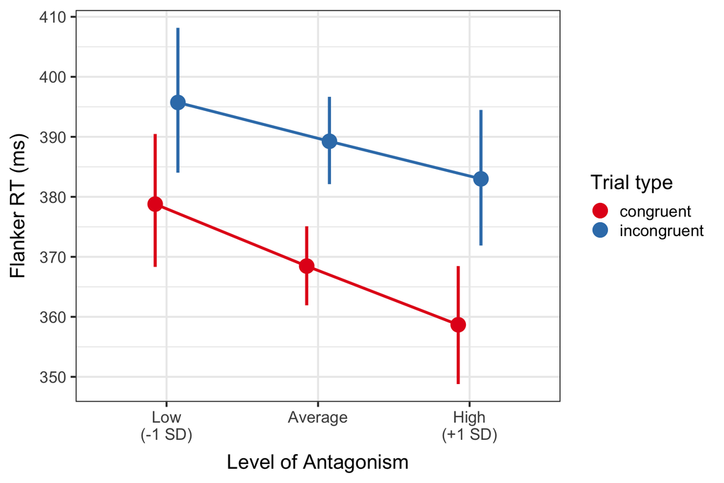

```r
pars <- mres$results$parameters$unstandardized %>%
  filter(paramHeader=="New.Additional.Parameters" & grepl("^RT", param)) %>%
  mutate_at(vars(est, lower_2.5ci, upper_2.5ci), list(~-1000/.)) %>% #re-invert to milliseconds
  mutate(congruency=if_else(grepl("RT_I", param), "incongruent", "congruent"),
         trait=if_else(grepl("A$", param), "antagonism", "constraint"),
         level=ordered(case_when(
           grepl("LO", param) ~ "Low\n(-1 SD)",
           grepl("MI", param) ~ "Average",
           grepl("HI", param) ~ "High\n(+1 SD)"), levels=c("Low\n(-1 SD)", "Average", "High\n(+1 SD)"))
  )

#as one would expect (based on coefs), constraint show little traction
# ggplot(pars, aes(x=level, y=est, ymin=lower_2.5ci, ymax=upper_2.5ci, color=congruency)) +
#   geom_pointrange(position=position_dodge(width=0.3)) + facet_wrap(~trait)

gg <- ggplot(pars %>% filter(trait=="antagonism"),
             aes(x=level, y=est, ymin=lower_2.5ci, ymax=upper_2.5ci, color=congruency)) +
  geom_pointrange(position=position_dodge(width=0.3), size=1.3) +
  geom_line(aes(x=as.numeric(level)), position=position_dodge(width=0.3), size=1.2) + theme_bw(base_size=18) +
  xlab("Level of Antagonism") + ylab("Flanker RT (ms)") + scale_color_brewer("Trial type", palette="Set1") +
  theme(axis.title.x=element_text(margin=margin(t=10)),
        axis.title.y=element_text(margin=margin(r=10)))

plot(gg)
```

```r
ggsave("Flanker Antagonism Predicted RTs.pdf", width=6, height=4.5, useDingbats=FALSE)

#difference in incon - con RT
pars %>% dplyr::select(trait, level, est, congruency) %>%
  pivot_wider(names_from=congruency, values_from=est) %>% mutate(diff=incongruent-congruent) %>% kable()
```

[output not shown]

# Add K10 to test for specificity

```r
AC_msem <- mplusObject(
  TITLE="Antagonism and Constraint BSEM CFA 3+3 Parcels, K10, Flanker RT",
  DEFINE="
    p1=MEAN(MISTRUST MPS_alR);
    p2=MEAN(PROPER MPS_tdR);
    p3=MEAN(MPS_clR IMPUL);
    p4=MEAN(MPS_acR HDWK);
    p5=MEAN(MPS_agR AGG);
    cond = cond - 1; ! 0=congruent, 1=incongruent
    block = block - 1; ! 0=most_incon, 1=most_con
    cond_block = cond*block; ! 1=most_con, incongruent
  ",

  VARIABLE = "
    WITHIN = cond block cond_block prev_rt_z prev_error trial_z run_trial_z;
    USEVARIABLES = id rt_inv cond block prev_rt_z
      prev_error trial_z run_trial_z
      MANIP K10 p1 p2 p3 p4 p5 cond_block;
    BETWEEN = MANIP K10 p1 p2 p3 p4 p5;
    CLUSTER = id;
  ",
  ANALYSIS = "
    TYPE=TWOLEVEL RANDOM;
    ESTIMATOR=BAYES;
    BITERATIONS=(15000);
    CHAINS=4;
    PROCESSORS=4;
  ",
  MODEL = "

  %WITHIN%
    rt_inv ON block cond_block;
    condslo | rt_inv ON cond;        !random slope of cond
    prevslo | rt_inv ON prev_rt_z;   !random slope of rt autocorrelation
    errslo | rt_inv ON prev_error;   !random slope of previous error
    runslo | rt_inv ON run_trial_z;  !random slope of run_trial
    trialslo | rt_inv ON trial_z;    !random slope of trial

  %BETWEEN%
    !means of random slopes
    [condslo];
    [runslo];
    [trialslo];
    [prevslo];
    [errslo];

    !variances of random slopes
    condslo;
    runslo;
    trialslo;
    prevslo;
    errslo;

    !slope correlations
    condslo runslo trialslo prevslo errslo WITH
       condslo runslo trialslo prevslo errslo;

    [rt_inv]; !mean average inverse RT

    !TRAIT MODEL

    antag BY p5* ! MPS_agR AGG
      p1        ! MISTRUST MPS_alR
      MANIP;
    antag@1;

    constraint BY
      p2*  !PROPER MPS_tdR
      p3  !MPS_clR IMPUL
      p4; !MPS_acR HDWK;
    constraint@1;

    antag WITH constraint;

    !TRAIT MODERATION

    ! trait moderates flanker performance
    condslo ON antag constraint K10;
    prevslo ON antag constraint K10;
    errslo ON antag constraint K10;

    !N.B. Leaving out the association of antag with rt_inv
    !omits a hugely important relationship.
    !Thus, allow antag as a predictor of average (person) RT
    rt_inv ON antag constraint K10;
  ",
  PLOT = "TYPE = PLOT2;",
  OUTPUT ="
    TECH1 TECH8 STANDARDIZED CINTERVAL;
  ",
  rdata=for_msem
)
```

```
## R variables selected automatically as any variable name that
## occurs in the MODEL, VARIABLE, or DEFINE section.
```

```
## The following variables are not unique in the first 8 characters:
##  run_trial_z, prev_rt_z
```

```r
mres <- mplusModeler(AC_msem, modelout = file.path("rt_m17_AC_k10.inp"),
                     run=TRUE, hashfilename = FALSE,
                     Mplus_command = mpluscmd)
```

```
## When hashfilename = FALSE, writeData cannot be 'ifmissing', setting to 'always'
```

```
## Wrote model to: rt_m17_AC_k10.inp
```

```
## Wrote data to: rt_m17_AC_k10.dat
```

```
## Factors will be converted to numbers in Mplus data file
```

```
##
## Factor: cond
## Conversion:
##        level number
##    congruent      1
##  incongruent      2
##
## Factor: block
## Conversion:
##       level number
##  most_incon      1
##    most_con      2
```

```
## The file(s)
##  'rt_m17_AC_k10.dat'
## currently exist(s) and will be overwritten
```

```
##
## Running model: rt_m17_AC_k10.inp
## System command: cd "/Users/mnh5174/Data_Analysis/PD_Inhibition_DDM/Code/mlm/flanker" && "/Users/mnh5174/Applications/Mplus/mplus" "rt_m17_AC_k10.inp"
## Reading model:  rt_m17_AC_k10.out
```

```r
summary(mres)
```

```
##  Antagonism and Constraint BSEM CFA 3+3 Parcels, K10, Flanker RTEstimated using BAYES
## Number of obs: 15504, number of (free) parameters: 56
##
## Fit Indices:
##
## CFI = NA, TLI = NA, SRMR = NA
## RMSEA = NA, 90% CI [NA, NA], p < .05 = NA
## AIC = NA, BIC = NA
```

```r
kable(mres$results$parameters$stdyx.standardized %>%
        filter(!paramHeader %in% c("Intercepts", "Means", "Residual Variances")))
```

| paramHeader | param | est | posterior_sd | pval | lower_2.5ci | upper_2.5ci | sig | BetweenWithin |
| --- | --- | --- | --- | --- | --- | --- | --- | --- |
| CONDSLO\|RT_INV.ON | COND | 0.159 | 0.012 | 0.000 | 0.137 | 0.182 | TRUE | Within.Std.Averaged.Over.Clusters |
| PREVSLO\|RT_INV.ON | PREV_RT_Z | 0.253 | 0.007 | 0.000 | 0.237 | 0.267 | TRUE | Within.Std.Averaged.Over.Clusters |
| ERRSLO\|RT_INV.ON | PREV_ERROR | 0.085 | 0.007 | 0.000 | 0.072 | 0.098 | TRUE | Within.Std.Averaged.Over.Clusters |
| RUNSLO\|RT_INV.ON | RUN_TRIAL_ | -0.008 | 0.008 | 0.154 | -0.023 | 0.007 | FALSE | Within.Std.Averaged.Over.Clusters |
| TRIALSLO\|RT_INV.ON | TRIAL_Z | -0.043 | 0.008 | 0.000 | -0.058 | -0.028 | TRUE | Within.Std.Averaged.Over.Clusters |
| RT_INV.ON | BLOCK | 0.032 | 0.012 | 0.004 | 0.009 | 0.055 | TRUE | Within.Std.Averaged.Over.Clusters |
| RT_INV.ON | COND_BLOCK | 0.047 | 0.012 | 0.000 | 0.024 | 0.070 | TRUE | Within.Std.Averaged.Over.Clusters |
| Residual.Variances | RT_INV | 0.831 | 0.005 | 0.000 | 0.821 | 0.841 | TRUE | Within.Std.Averaged.Over.Clusters |
| ANTAG.BY | P5 | 0.756 | 0.073 | 0.000 | 0.597 | 0.885 | TRUE | Between |
| ANTAG.BY | P1 | 0.617 | 0.085 | 0.000 | 0.433 | 0.763 | TRUE | Between |
| ANTAG.BY | MANIP | 0.814 | 0.070 | 0.000 | 0.662 | 0.936 | TRUE | Between |
| CONSTRAI.BY | P2 | 0.760 | 0.113 | 0.000 | 0.511 | 0.950 | TRUE | Between |
| CONSTRAI.BY | P3 | 0.578 | 0.110 | 0.000 | 0.354 | 0.788 | TRUE | Between |
| CONSTRAI.BY | P4 | 0.486 | 0.109 | 0.000 | 0.258 | 0.683 | TRUE | Between |
| CONDSLO.ON | ANTAG | 0.361 | 0.159 | 0.019 | 0.023 | 0.641 | TRUE | Between |
| CONDSLO.ON | CONSTRAINT | -0.082 | 0.163 | 0.309 | -0.389 | 0.247 | FALSE | Between |
| PREVSLO.ON | ANTAG | -0.032 | 0.156 | 0.421 | -0.339 | 0.274 | FALSE | Between |
| PREVSLO.ON | CONSTRAINT | -0.349 | 0.150 | 0.015 | -0.620 | -0.037 | TRUE | Between |
| ERRSLO.ON | ANTAG | 0.018 | 0.171 | 0.459 | -0.316 | 0.348 | FALSE | Between |
| ERRSLO.ON | CONSTRAINT | -0.034 | 0.168 | 0.421 | -0.361 | 0.295 | FALSE | Between |
| CONDSLO.ON | K10 | 0.132 | 0.102 | 0.097 | -0.061 | 0.338 | FALSE | Between |
| PREVSLO.ON | K10 | -0.010 | 0.098 | 0.461 | -0.202 | 0.184 | FALSE | Between |
| ERRSLO.ON | K10 | -0.124 | 0.115 | 0.148 | -0.339 | 0.105 | FALSE | Between |
| RT_INV.ON | ANTAG | -0.240 | 0.125 | 0.033 | -0.473 | 0.016 | FALSE | Between |
| RT_INV.ON | CONSTRAINT | 0.086 | 0.127 | 0.255 | -0.172 | 0.328 | FALSE | Between |
| RT_INV.ON | K10 | -0.061 | 0.075 | 0.207 | -0.207 | 0.084 | FALSE | Between |
| CONDSLO.WITH | RUNSLO | -0.019 | 0.191 | 0.464 | -0.389 | 0.358 | FALSE | Between |
| CONDSLO.WITH | TRIALSLO | -0.288 | 0.172 | 0.058 | -0.595 | 0.074 | FALSE | Between |
| CONDSLO.WITH | PREVSLO | -0.173 | 0.199 | 0.202 | -0.543 | 0.229 | FALSE | Between |
| CONDSLO.WITH | ERRSLO | -0.233 | 0.223 | 0.158 | -0.647 | 0.221 | FALSE | Between |
| RUNSLO.WITH | TRIALSLO | 0.044 | 0.162 | 0.398 | -0.274 | 0.358 | FALSE | Between |
| RUNSLO.WITH | PREVSLO | -0.128 | 0.177 | 0.246 | -0.461 | 0.230 | FALSE | Between |
| RUNSLO.WITH | ERRSLO | -0.151 | 0.188 | 0.221 | -0.502 | 0.225 | FALSE | Between |
| TRIALSLO.WITH | PREVSLO | -0.019 | 0.162 | 0.455 | -0.331 | 0.296 | FALSE | Between |
| TRIALSLO.WITH | ERRSLO | 0.046 | 0.181 | 0.403 | -0.308 | 0.396 | FALSE | Between |
| PREVSLO.WITH | ERRSLO | 0.404 | 0.193 | 0.031 | -0.021 | 0.735 | FALSE | Between |
| ANTAG.WITH | CONSTRAINT | -0.175 | 0.143 | 0.116 | -0.451 | 0.106 | FALSE | Between |
| Variances | ANTAG | 1.000 | 0.000 | 0.000 | 1.000 | 1.000 | FALSE | Between |
| Variances | CONSTRAINT | 1.000 | 0.000 | 0.000 | 1.000 | 1.000 | FALSE | Between |
| Variances | RUNSLO | 1.000 | 0.000 | 0.000 | 1.000 | 1.000 | FALSE | Between |
| Variances | TRIALSLO | 1.000 | 0.000 | 0.000 | 1.000 | 1.000 | FALSE | Between |
| Residual.Variances | MANIP | 0.337 | 0.111 | 0.000 | 0.124 | 0.561 | TRUE | Between |
| Residual.Variances | P1 | 0.619 | 0.102 | 0.000 | 0.418 | 0.812 | TRUE | Between |
| Residual.Variances | P2 | 0.422 | 0.166 | 0.000 | 0.097 | 0.739 | TRUE | Between |
| Residual.Variances | P3 | 0.666 | 0.127 | 0.000 | 0.379 | 0.875 | TRUE | Between |
| Residual.Variances | P4 | 0.763 | 0.104 | 0.000 | 0.533 | 0.934 | TRUE | Between |
| Residual.Variances | P5 | 0.429 | 0.109 | 0.000 | 0.216 | 0.644 | TRUE | Between |
| Residual.Variances | RT_INV | 0.902 | 0.063 | 0.000 | 0.742 | 0.983 | TRUE | Between |
| Residual.Variances | CONDSLO | 0.798 | 0.107 | 0.000 | 0.542 | 0.952 | TRUE | Between |
| Residual.Variances | PREVSLO | 0.848 | 0.101 | 0.000 | 0.600 | 0.980 | TRUE | Between |
| Residual.Variances | ERRSLO | 0.930 | 0.063 | 0.000 | 0.755 | 0.993 | TRUE | Between |

# Add STAI to test for specificity

```r
AC_msem <- mplusObject(
  TITLE="Antagonism and Constraint BSEM CFA 3+3 Parcels, STAI, Flanker RT",
  DEFINE="
    p1=MEAN(MISTRUST MPS_alR);
    p2=MEAN(PROPER MPS_tdR);
    p3=MEAN(MPS_clR IMPUL);
    p4=MEAN(MPS_acR HDWK);
    p5=MEAN(MPS_agR AGG);
    cond = cond - 1; ! 0=congruent, 1=incongruent
    block = block - 1; ! 0=most_incon, 1=most_con
    cond_block = cond*block; ! 1=most_con, incongruent
  ",

  VARIABLE = "
    WITHIN = cond block cond_block prev_rt_z prev_error trial_z run_trial_z;
    USEVARIABLES = id rt_inv cond block prev_rt_z
      prev_error trial_z run_trial_z
      MANIP STAI p1 p2 p3 p4 p5 cond_block;
    BETWEEN = MANIP STAI p1 p2 p3 p4 p5;
    CLUSTER = id;
  ",
  ANALYSIS = "
    TYPE=TWOLEVEL RANDOM;
    ESTIMATOR=BAYES;
    BITERATIONS=(15000);
    CHAINS=4;
    PROCESSORS=4;
  ",
  MODEL = "

  %WITHIN%
    rt_inv ON block cond_block;
    condslo | rt_inv ON cond;        !random slope of cond
    prevslo | rt_inv ON prev_rt_z;   !random slope of rt autocorrelation
    errslo | rt_inv ON prev_error;   !random slope of previous error
    runslo | rt_inv ON run_trial_z;  !random slope of run_trial
    trialslo | rt_inv ON trial_z;    !random slope of trial

  %BETWEEN%
    !means of random slopes
    [condslo];
    [runslo];
    [trialslo];
    [prevslo];
    [errslo];

    !variances of random slopes
    condslo;
    runslo;
    trialslo;
    prevslo;
    errslo;

    !slope correlations
    condslo runslo trialslo prevslo errslo WITH
       condslo runslo trialslo prevslo errslo;

    [rt_inv]; !mean average inverse RT

    !TRAIT MODEL

    antag BY p5* ! MPS_agR AGG
      p1        ! MISTRUST MPS_alR
      MANIP;
    antag@1;

    constraint BY
      p2*  !PROPER MPS_tdR
      p3  !MPS_clR IMPUL
      p4; !MPS_acR HDWK;
    constraint@1;

    antag WITH constraint;

    !TRAIT MODERATION

    ! trait moderates flanker performance
    condslo ON antag constraint STAI;
    prevslo ON antag constraint STAI;
    errslo ON antag constraint STAI;

    !N.B. Leaving out the association of antag with rt_inv
    !omits a hugely important relationship.
    !Thus, allow antag as a predictor of average (person) RT
    rt_inv ON antag constraint STAI;
  ",
  PLOT = "TYPE = PLOT2;",
  OUTPUT ="
    TECH1 TECH8 STANDARDIZED CINTERVAL;
  ",
  rdata=for_msem
)
```

```
## R variables selected automatically as any variable name that
## occurs in the MODEL, VARIABLE, or DEFINE section.
```

```
## The following variables are not unique in the first 8 characters:
##  run_trial_z, prev_rt_z
```

```r
mres <- mplusModeler(AC_msem, modelout = file.path("rt_m17_AC_stai.inp"),
                     run=TRUE, hashfilename = FALSE,
                     Mplus_command = mpluscmd)
```

```
## When hashfilename = FALSE, writeData cannot be 'ifmissing', setting to 'always'
```

```
## Wrote model to: rt_m17_AC_stai.inp
```

```
## Wrote data to: rt_m17_AC_stai.dat
```

```
## Factors will be converted to numbers in Mplus data file
```

```
##
## Factor: cond
## Conversion:
##        level number
##    congruent      1
##  incongruent      2
##
## Factor: block
## Conversion:
##       level number
##  most_incon      1
##    most_con      2
```

```
## The file(s)
##  'rt_m17_AC_stai.dat'
## currently exist(s) and will be overwritten
```

```
##
## Running model: rt_m17_AC_stai.inp
## System command: cd "/Users/mnh5174/Data_Analysis/PD_Inhibition_DDM/Code/mlm/flanker" && "/Users/mnh5174/Applications/Mplus/mplus" "rt_m17_AC_stai.inp"
## Reading model:  rt_m17_AC_stai.out
```

```r
summary(mres)
```

```
##  Antagonism and Constraint BSEM CFA 3+3 Parcels, STAI, Flanker RTEstimated using BAYES
## Number of obs: 15349, number of (free) parameters: 56
##
## Fit Indices:
##
## CFI = NA, TLI = NA, SRMR = NA
## RMSEA = NA, 90% CI [NA, NA], p < .05 = NA
## AIC = NA, BIC = NA
```

```r
kable(mres$results$parameters$stdyx.standardized %>%
        filter(!paramHeader %in% c("Intercepts", "Means", "Residual Variances")))
```

| paramHeader | param | est | posterior_sd | pval | lower_2.5ci | upper_2.5ci | sig | BetweenWithin |
| --- | --- | --- | --- | --- | --- | --- | --- | --- |
| CONDSLO\|RT_INV.ON | COND | 0.157 | 0.012 | 0.000 | 0.133 | 0.180 | TRUE | Within.Std.Averaged.Over.Clusters |
| PREVSLO\|RT_INV.ON | PREV_RT_Z | 0.252 | 0.007 | 0.000 | 0.238 | 0.267 | TRUE | Within.Std.Averaged.Over.Clusters |
| ERRSLO\|RT_INV.ON | PREV_ERROR | 0.085 | 0.007 | 0.000 | 0.072 | 0.097 | TRUE | Within.Std.Averaged.Over.Clusters |
| RUNSLO\|RT_INV.ON | RUN_TRIAL_ | -0.010 | 0.008 | 0.103 | -0.025 | 0.005 | FALSE | Within.Std.Averaged.Over.Clusters |
| TRIALSLO\|RT_INV.ON | TRIAL_Z | -0.040 | 0.008 | 0.000 | -0.055 | -0.025 | TRUE | Within.Std.Averaged.Over.Clusters |
| RT_INV.ON | BLOCK | 0.032 | 0.012 | 0.004 | 0.008 | 0.054 | TRUE | Within.Std.Averaged.Over.Clusters |
| RT_INV.ON | COND_BLOCK | 0.047 | 0.012 | 0.000 | 0.022 | 0.071 | TRUE | Within.Std.Averaged.Over.Clusters |
| Residual.Variances | RT_INV | 0.831 | 0.005 | 0.000 | 0.822 | 0.841 | TRUE | Within.Std.Averaged.Over.Clusters |
| ANTAG.BY | P5 | 0.747 | 0.072 | 0.000 | 0.588 | 0.870 | TRUE | Between |
| ANTAG.BY | P1 | 0.635 | 0.085 | 0.000 | 0.450 | 0.783 | TRUE | Between |
| ANTAG.BY | MANIP | 0.809 | 0.068 | 0.000 | 0.654 | 0.922 | TRUE | Between |
| CONSTRAI.BY | P2 | 0.731 | 0.117 | 0.000 | 0.479 | 0.939 | TRUE | Between |
| CONSTRAI.BY | P3 | 0.596 | 0.115 | 0.000 | 0.356 | 0.811 | TRUE | Between |
| CONSTRAI.BY | P4 | 0.475 | 0.113 | 0.000 | 0.243 | 0.681 | TRUE | Between |
| CONDSLO.ON | ANTAG | 0.457 | 0.146 | 0.003 | 0.144 | 0.714 | TRUE | Between |
| CONDSLO.ON | CONSTRAINT | -0.012 | 0.164 | 0.471 | -0.319 | 0.315 | FALSE | Between |
| PREVSLO.ON | ANTAG | -0.107 | 0.155 | 0.249 | -0.401 | 0.202 | FALSE | Between |
| PREVSLO.ON | CONSTRAINT | -0.354 | 0.154 | 0.017 | -0.630 | -0.027 | TRUE | Between |
| ERRSLO.ON | ANTAG | -0.007 | 0.170 | 0.484 | -0.341 | 0.322 | FALSE | Between |
| ERRSLO.ON | CONSTRAINT | -0.056 | 0.175 | 0.376 | -0.397 | 0.286 | FALSE | Between |
| CONDSLO.ON | STAI | -0.039 | 0.089 | 0.334 | -0.204 | 0.146 | FALSE | Between |
| PREVSLO.ON | STAI | 0.133 | 0.091 | 0.079 | -0.051 | 0.306 | FALSE | Between |
| ERRSLO.ON | STAI | -0.111 | 0.111 | 0.167 | -0.321 | 0.111 | FALSE | Between |
| RT_INV.ON | ANTAG | -0.316 | 0.119 | 0.007 | -0.530 | -0.065 | TRUE | Between |
| RT_INV.ON | CONSTRAINT | 0.056 | 0.131 | 0.337 | -0.208 | 0.302 | FALSE | Between |
| RT_INV.ON | STAI | 0.070 | 0.071 | 0.166 | -0.073 | 0.205 | FALSE | Between |
| CONDSLO.WITH | RUNSLO | -0.101 | 0.190 | 0.300 | -0.465 | 0.279 | FALSE | Between |
| CONDSLO.WITH | TRIALSLO | -0.328 | 0.166 | 0.031 | -0.627 | 0.017 | FALSE | Between |
| CONDSLO.WITH | PREVSLO | -0.143 | 0.201 | 0.243 | -0.524 | 0.262 | FALSE | Between |
| CONDSLO.WITH | ERRSLO | -0.254 | 0.216 | 0.135 | -0.645 | 0.193 | FALSE | Between |
| RUNSLO.WITH | TRIALSLO | 0.083 | 0.163 | 0.309 | -0.239 | 0.395 | FALSE | Between |
| RUNSLO.WITH | PREVSLO | -0.074 | 0.179 | 0.347 | -0.416 | 0.277 | FALSE | Between |
| RUNSLO.WITH | ERRSLO | -0.146 | 0.194 | 0.233 | -0.510 | 0.244 | FALSE | Between |
| TRIALSLO.WITH | PREVSLO | 0.006 | 0.159 | 0.483 | -0.304 | 0.317 | FALSE | Between |
| TRIALSLO.WITH | ERRSLO | 0.058 | 0.177 | 0.372 | -0.289 | 0.397 | FALSE | Between |
| PREVSLO.WITH | ERRSLO | 0.401 | 0.192 | 0.030 | -0.015 | 0.730 | FALSE | Between |
| ANTAG.WITH | CONSTRAINT | -0.164 | 0.150 | 0.141 | -0.450 | 0.134 | FALSE | Between |
| Variances | ANTAG | 1.000 | 0.000 | 0.000 | 1.000 | 1.000 | FALSE | Between |
| Variances | CONSTRAINT | 1.000 | 0.000 | 0.000 | 1.000 | 1.000 | FALSE | Between |
| Variances | RUNSLO | 1.000 | 0.000 | 0.000 | 1.000 | 1.000 | FALSE | Between |
| Variances | TRIALSLO | 1.000 | 0.000 | 0.000 | 1.000 | 1.000 | FALSE | Between |
| Residual.Variances | MANIP | 0.345 | 0.107 | 0.000 | 0.151 | 0.572 | TRUE | Between |
| Residual.Variances | P1 | 0.597 | 0.105 | 0.000 | 0.388 | 0.797 | TRUE | Between |
| Residual.Variances | P2 | 0.466 | 0.167 | 0.000 | 0.119 | 0.770 | TRUE | Between |
| Residual.Variances | P3 | 0.645 | 0.136 | 0.000 | 0.342 | 0.873 | TRUE | Between |
| Residual.Variances | P4 | 0.774 | 0.105 | 0.000 | 0.536 | 0.941 | TRUE | Between |
| Residual.Variances | P5 | 0.441 | 0.105 | 0.000 | 0.243 | 0.654 | TRUE | Between |
| Residual.Variances | RT_INV | 0.866 | 0.078 | 0.000 | 0.681 | 0.978 | TRUE | Between |
| Residual.Variances | CONDSLO | 0.759 | 0.127 | 0.000 | 0.467 | 0.952 | TRUE | Between |
| Residual.Variances | PREVSLO | 0.826 | 0.109 | 0.000 | 0.561 | 0.975 | TRUE | Between |
| Residual.Variances | ERRSLO | 0.930 | 0.063 | 0.000 | 0.754 | 0.993 | TRUE | Between |

# Extraversion MSEM

Here is the full model from the between-person analysis in Trait_Structure. It gets very finicky, though, basically sending the model off the rails. On further examination, both in the parceled model and the full indicator model, the problem emerges primarily from having a fixed factor loading for identification (unit loading identification). When we switch to unit variance identification (standardizing the factor), the model converges very nicely (even with very high iterations). Thus, switch to this identification approach for estimability.

For the full model, I get an Mplus error

```
*** FATAL ERROR

     STANDARDIZED COEFFICIENTS ARE NOT AVAILABLE FOR THIS MODEL.
     THIS CAN BE RESOLVED BY ADDING REGRESSION ON STATEMENTS FOR ALL DEPENDENT VARIABLES.
```

I’ve turned off standardized output for now. I think it’s due to the residual correlation in the factor.

```r
tofactor <- self_reps %>% dplyr::select(subject, POSTEMP, EXHIB, ENTITL, DETACH, MPS_wbR, MPS_spR, MPS_scR) %>%
  mutate(MPS_scR=-1*MPS_scR) %>% #rescore in direction of detachment (higher scores are bad)
  mutate_at(vars(-subject), list(~as.vector(scale(.)))) %>%
  dplyr::rename(id=subject)

for_msem <- flanker %>% inner_join(tofactor, by="id")
anti_join(tofactor, flanker, by="id")
```

```
##   id POSTEMP  EXHIB ENTITL  DETACH MPS_wbR  MPS_spR MPS_scR
## 1 44  0.1209 -0.276 -0.491 -0.8406   0.444  0.94795  -0.459
## 2 47 -0.2284 -1.273  0.041  0.0944   0.109 -0.32005   0.695
## 3 55  0.1209  0.223  0.041 -0.1394  -1.230 -0.32005   0.311
## 4 83 -0.0537 -0.276  0.840  0.0944   1.114 -0.00305  -0.074
```

```r
E_msem <- mplusObject(
  TITLE="Extraversion and Detachment MSEM Flanker RT",
  DEFINE="
    cond = cond - 1; ! 0=congruent, 1=incongruent
    block = block - 1; ! 0=most_incon, 1=most_con
    cond_block = cond*block; ! 1=most_con, incongruent
  ",

  VARIABLE = "
    WITHIN = cond block cond_block prev_rt_z prev_error trial_z run_trial_z;
    USEVARIABLES = id rt_inv cond block prev_rt_z
      prev_error trial_z run_trial_z
      POSTEMP EXHIB ENTITL DETACH MPS_wbR MPS_spR MPS_scR cond_block;
    BETWEEN = POSTEMP EXHIB ENTITL DETACH MPS_wbR MPS_spR MPS_scR;
    CLUSTER = id;
  ",
  ANALYSIS = "
    TYPE=TWOLEVEL RANDOM;
    ESTIMATOR=BAYES;
    BITERATIONS=(20000);
    CHAINS=4;
    PROCESSORS=4;
  ",
  MODEL = "

  %WITHIN%
    rt_inv ON block cond_block;
    condslo | rt_inv ON cond;        !random slope of cond
    prevslo | rt_inv ON prev_rt_z;   !random slope of rt autocorrelation
    errslo | rt_inv ON prev_error;   !random slope of previous error
    runslo | rt_inv ON run_trial_z;  !random slope of run_trial
    trialslo | rt_inv ON trial_z;    !random slope of trial


  %BETWEEN%
    !means of random slopes
    [condslo];
    [runslo];
    [trialslo];
    [prevslo];
    [errslo];

    !variances of random slopes
    condslo;
    runslo;
    trialslo;
    prevslo;
    errslo;

    !slope correlations
    condslo runslo trialslo prevslo errslo WITH
       condslo runslo trialslo prevslo errslo;

    [rt_inv]; !mean average inverse RT

    !TRAIT MODEL
    agentic BY MPS_spR* EXHIB ENTITL POSTEMP MPS_wbR;
    agentic@1;

    affiliat BY MPS_scR*1 DETACH;
    affiliat@1;

    agentic WITH affiliat;
    MPS_SPR WITH EXHIB;
    !DETACH@0;  !heywood case in MLR, okay in Bayes (force positive variance)

    !TRAIT MODERATION

    ! trait moderates flanker performance -- incongruency effect and stickiness of RT
    condslo ON agentic affiliat;
    prevslo ON agentic affiliat;

    errslo ON agentic affiliat;

    !N.B. Leaving out the association of antag with rt_inv
    !omits a hugely important relationship.
    !Thus, allow antag as a predictor of average (person) RT
    rt_inv ON agentic affiliat;
  ",
  PLOT = "TYPE = PLOT2;",
  OUTPUT ="
    TECH1 TECH8 CINTERVAL;
  ",
  rdata=for_msem
)
```

```
## R variables selected automatically as any variable name that
## occurs in the MODEL, VARIABLE, or DEFINE section.
```

```
## The following variables are not unique in the first 8 characters:
##  run_trial_z
```

```r
mres <- mplusModeler(E_msem, modelout = file.path("rt_m17_E.inp"),
                     run=TRUE, hashfilename = FALSE,
                     Mplus_command = mpluscmd)
```

```
## When hashfilename = FALSE, writeData cannot be 'ifmissing', setting to 'always'
```

```
## Wrote model to: rt_m17_E.inp
```

```
## Wrote data to: rt_m17_E.dat
```

```
## Factors will be converted to numbers in Mplus data file
```

```
##
## Factor: cond
## Conversion:
##        level number
##    congruent      1
##  incongruent      2
##
## Factor: block
## Conversion:
##       level number
##  most_incon      1
##    most_con      2
```

```
## The file(s)
##  'rt_m17_E.dat'
## currently exist(s) and will be overwritten
```

```
##
## Running model: rt_m17_E.inp
## System command: cd "/Users/mnh5174/Data_Analysis/PD_Inhibition_DDM/Code/mlm/flanker" && "/Users/mnh5174/Applications/Mplus/mplus" "rt_m17_E.inp"
## Reading model:  rt_m17_E.out
```

```r
summary(mres)
```

```
##  Extraversion and Detachment MSEM Flanker RTEstimated using BAYES
## Number of obs: 15504, number of (free) parameters: 56
##
## Fit Indices:
##
## CFI = NA, TLI = NA, SRMR = NA
## RMSEA = NA, 90% CI [NA, NA], p < .05 = NA
## AIC = NA, BIC = NA
```

```r
kable(mres$results$parameters$unstandardized %>%
        filter(!paramHeader %in% c("Intercepts", "Means", "Residual Variances")))
```

| paramHeader | param | est | posterior_sd | pval | lower_2.5ci | upper_2.5ci | sig | BetweenWithin |
| --- | --- | --- | --- | --- | --- | --- | --- | --- |
| RT_INV.ON | BLOCK | 0.024 | 0.009 | 0.002 | 0.007 | 0.042 | TRUE | Within |
| RT_INV.ON | COND_BLOCK | 0.049 | 0.012 | 0.000 | 0.025 | 0.073 | TRUE | Within |
| Residual.Variances | RT_INV | 0.117 | 0.001 | 0.000 | 0.114 | 0.119 | TRUE | Within |
| AGENTIC.BY | MPS_SPR | 0.479 | 0.112 | 0.000 | 0.266 | 0.703 | TRUE | Between |
| AGENTIC.BY | EXHIB | 0.489 | 0.111 | 0.000 | 0.279 | 0.713 | TRUE | Between |
| AGENTIC.BY | ENTITL | 0.383 | 0.114 | 0.000 | 0.164 | 0.612 | TRUE | Between |
| AGENTIC.BY | POSTEMP | 0.983 | 0.092 | 0.000 | 0.817 | 1.176 | TRUE | Between |
| AGENTIC.BY | MPS_WBR | 0.929 | 0.091 | 0.000 | 0.763 | 1.118 | TRUE | Between |
| AFFILIAT.BY | MPS_SCR | 0.934 | 0.093 | 0.000 | 0.763 | 1.127 | TRUE | Between |
| AFFILIAT.BY | DETACH | 0.993 | 0.089 | 0.000 | 0.824 | 1.175 | TRUE | Between |
| CONDSLO.ON | AGENTIC | 0.011 | 0.012 | 0.158 | -0.011 | 0.035 | FALSE | Between |
| CONDSLO.ON | AFFILIAT | 0.026 | 0.012 | 0.012 | 0.003 | 0.049 | TRUE | Between |
| PREVSLO.ON | AGENTIC | -0.020 | 0.010 | 0.018 | -0.039 | -0.001 | TRUE | Between |
| PREVSLO.ON | AFFILIAT | -0.012 | 0.009 | 0.095 | -0.031 | 0.006 | FALSE | Between |
| ERRSLO.ON | AGENTIC | 0.018 | 0.039 | 0.322 | -0.060 | 0.095 | FALSE | Between |
| ERRSLO.ON | AFFILIAT | 0.042 | 0.036 | 0.117 | -0.027 | 0.114 | FALSE | Between |
| RT_INV.ON | AGENTIC | 0.001 | 0.034 | 0.487 | -0.065 | 0.067 | FALSE | Between |
| RT_INV.ON | AFFILIAT | -0.023 | 0.033 | 0.239 | -0.088 | 0.041 | FALSE | Between |
| CONDSLO.WITH | RUNSLO | 0.000 | 0.000 | 0.355 | -0.001 | 0.001 | FALSE | Between |
| CONDSLO.WITH | TRIALSLO | -0.001 | 0.001 | 0.023 | -0.002 | 0.000 | TRUE | Between |
| CONDSLO.WITH | PREVSLO | 0.000 | 0.001 | 0.372 | -0.002 | 0.001 | FALSE | Between |
| CONDSLO.WITH | ERRSLO | -0.004 | 0.003 | 0.045 | -0.010 | 0.001 | FALSE | Between |
| RUNSLO.WITH | TRIALSLO | 0.000 | 0.000 | 0.384 | -0.001 | 0.001 | FALSE | Between |
| RUNSLO.WITH | PREVSLO | 0.000 | 0.000 | 0.188 | -0.001 | 0.000 | FALSE | Between |
| RUNSLO.WITH | ERRSLO | -0.001 | 0.001 | 0.232 | -0.003 | 0.001 | FALSE | Between |
| TRIALSLO.WITH | PREVSLO | 0.000 | 0.000 | 0.351 | -0.001 | 0.001 | FALSE | Between |
| TRIALSLO.WITH | ERRSLO | 0.001 | 0.002 | 0.272 | -0.003 | 0.005 | FALSE | Between |
| PREVSLO.WITH | ERRSLO | 0.004 | 0.002 | 0.020 | 0.000 | 0.009 | TRUE | Between |
| AGENTIC.WITH | AFFILIAT | -0.541 | 0.089 | 0.000 | -0.692 | -0.348 | TRUE | Between |
| MPS_SPR.WITH | EXHIB | 0.494 | 0.110 | 0.000 | 0.311 | 0.746 | TRUE | Between |
| Variances | AGENTIC | 1.000 | 0.000 | 0.000 | 1.000 | 1.000 | FALSE | Between |
| Variances | AFFILIAT | 1.000 | 0.000 | 0.000 | 1.000 | 1.000 | FALSE | Between |
| Variances | RUNSLO | 0.001 | 0.000 | 0.000 | 0.001 | 0.002 | TRUE | Between |
| Variances | TRIALSLO | 0.003 | 0.001 | 0.000 | 0.002 | 0.005 | TRUE | Between |
| Residual.Variances | POSTEMP | 0.184 | 0.073 | 0.000 | 0.044 | 0.337 | TRUE | Between |
| Residual.Variances | EXHIB | 0.855 | 0.133 | 0.000 | 0.644 | 1.162 | TRUE | Between |
| Residual.Variances | ENTITL | 0.932 | 0.142 | 0.000 | 0.710 | 1.262 | TRUE | Between |
| Residual.Variances | DETACH | 0.129 | 0.080 | 0.000 | 0.011 | 0.309 | TRUE | Between |
| Residual.Variances | MPS_WBR | 0.250 | 0.070 | 0.000 | 0.119 | 0.396 | TRUE | Between |
| Residual.Variances | MPS_SPR | 0.873 | 0.137 | 0.000 | 0.656 | 1.192 | TRUE | Between |
| Residual.Variances | MPS_SCR | 0.246 | 0.080 | 0.000 | 0.079 | 0.394 | TRUE | Between |
| Residual.Variances | RT_INV | 0.055 | 0.009 | 0.000 | 0.042 | 0.075 | TRUE | Between |
| Residual.Variances | CONDSLO | 0.004 | 0.001 | 0.000 | 0.002 | 0.007 | TRUE | Between |
| Residual.Variances | PREVSLO | 0.003 | 0.001 | 0.000 | 0.002 | 0.004 | TRUE | Between |
| Residual.Variances | ERRSLO | 0.034 | 0.011 | 0.000 | 0.017 | 0.060 | TRUE | Between |

## Parcel model

The parcel model goes off the rails if we fix the first loading to one, particularly for the (dis)affiliative factor. But if we standardize the factors manually, it will converge without issue (even running the chains out twice as long).

```r
E_msem_parcel <- mplusObject(
  TITLE="Extraversion and Detachment MSEM Flanker RT Parcel",
  DEFINE="
    p1 = MEAN(MPS_spR EXHIB);
    p2 = MEAN(POSTEMP MPS_wbR);
    cond = cond - 1; ! 0=congruent, 1=incongruent
    block = block - 1; ! 0=most_incon, 1=most_con
    cond_block = cond*block; ! 1=most_con, incongruent
  ",

  VARIABLE = "
    WITHIN = cond block cond_block prev_rt_z prev_error trial_z run_trial_z;
    USEVARIABLES = id rt_inv cond block prev_rt_z
      prev_error trial_z run_trial_z
      ENTITL DETACH MPS_scR p1 p2 cond_block;
    BETWEEN = ENTITL DETACH MPS_scR p1 p2;
    CLUSTER = id;
  ",
  ANALYSIS = "
    TYPE=TWOLEVEL RANDOM;
    ESTIMATOR=BAYES;
    BITERATIONS=(20000);
    CHAINS=4;
    PROCESSORS=4;
  ",
  MODEL = "

  %WITHIN%
    rt_inv ON block cond_block;
    condslo | rt_inv ON cond;        !random slope of cond
    prevslo | rt_inv ON prev_rt_z;   !random slope of rt autocorrelation
    errslo | rt_inv ON prev_error;   !random slope of previous error
    runslo | rt_inv ON run_trial_z;  !random slope of run_trial
    trialslo | rt_inv ON trial_z;    !random slope of trial

  %BETWEEN%
    !means of random slopes
    [condslo];
    [runslo];
    [trialslo];
    [prevslo];
    [errslo];

    !variances of random slopes
    condslo;
    runslo;
    trialslo;
    prevslo;
    errslo;

    !slope correlations
    condslo runslo trialslo prevslo errslo WITH
       condslo runslo trialslo prevslo errslo;

    [rt_inv]; !mean average inverse RT

    !TRAIT MODEL

    agentic BY p1*1 !MPS_spR EXHIB
      p2 !POSTEMP MPS_wbR
      ENTITL;

    agentic@1;

    affiliat BY MPS_scR*1 DETACH;
    affiliat@1;

    agentic WITH affiliat;

    !TRAIT MODERATION

    ! trait moderates flanker performance -- incongruency effect and stickiness of RT
    condslo ON agentic affiliat;
    prevslo ON agentic affiliat;
    errslo ON agentic affiliat;

    !N.B. Leaving out the association of antag with rt_inv
    !omits a hugely important relationship.
    !Thus, allow antag as a predictor of average (person) RT
    rt_inv ON agentic affiliat;
  ",
  PLOT = "TYPE = PLOT2;",
  OUTPUT ="
    TECH1 TECH8 CINTERVAL STANDARDIZED;
  ",
  rdata=for_msem
)
```

```
## R variables selected automatically as any variable name that
## occurs in the MODEL, VARIABLE, or DEFINE section.
```

```
## The following variables are not unique in the first 8 characters:
##  run_trial_z
```

```r
mres <- mplusModeler(E_msem_parcel, modelout = file.path("rt_m17_E_parcel.inp"),
                     run=TRUE, hashfilename = FALSE,
                     Mplus_command = mpluscmd)
```

```
## When hashfilename = FALSE, writeData cannot be 'ifmissing', setting to 'always'
```

```
## Wrote model to: rt_m17_E_parcel.inp
```

```
## Wrote data to: rt_m17_E_parcel.dat
```

```
## Factors will be converted to numbers in Mplus data file
```

```
##
## Factor: cond
## Conversion:
##        level number
##    congruent      1
##  incongruent      2
##
## Factor: block
## Conversion:
##       level number
##  most_incon      1
##    most_con      2
```

```
## The file(s)
##  'rt_m17_E_parcel.dat'
## currently exist(s) and will be overwritten
```

```
##
## Running model: rt_m17_E_parcel.inp
## System command: cd "/Users/mnh5174/Data_Analysis/PD_Inhibition_DDM/Code/mlm/flanker" && "/Users/mnh5174/Applications/Mplus/mplus" "rt_m17_E_parcel.inp"
## Reading model:  rt_m17_E_parcel.out
```

```r
summary(mres)
```

```
##  Extraversion and Detachment MSEM Flanker RT ParcelEstimated using BAYES
## Number of obs: 15504, number of (free) parameters: 49
##
## Fit Indices:
##
## CFI = NA, TLI = NA, SRMR = NA
## RMSEA = NA, 90% CI [NA, NA], p < .05 = NA
## AIC = NA, BIC = NA
```

```r
kable(mres$results$parameters$stdyx.standardized %>%
        filter(!paramHeader %in% c("Intercepts", "Means", "Residual Variances")))
```

| paramHeader | param | est | posterior_sd | pval | lower_2.5ci | upper_2.5ci | sig | BetweenWithin |
| --- | --- | --- | --- | --- | --- | --- | --- | --- |
| CONDSLO\|RT_INV.ON | COND | 0.160 | 0.011 | 0.000 | 0.137 | 0.182 | TRUE | Within.Std.Averaged.Over.Clusters |
| PREVSLO\|RT_INV.ON | PREV_RT_Z | 0.252 | 0.007 | 0.000 | 0.237 | 0.266 | TRUE | Within.Std.Averaged.Over.Clusters |
| ERRSLO\|RT_INV.ON | PREV_ERROR | 0.085 | 0.007 | 0.000 | 0.072 | 0.099 | TRUE | Within.Std.Averaged.Over.Clusters |
| RUNSLO\|RT_INV.ON | RUN_TRIAL_ | -0.008 | 0.008 | 0.147 | -0.024 | 0.006 | FALSE | Within.Std.Averaged.Over.Clusters |
| TRIALSLO\|RT_INV.ON | TRIAL_Z | -0.043 | 0.008 | 0.000 | -0.059 | -0.028 | TRUE | Within.Std.Averaged.Over.Clusters |
| RT_INV.ON | BLOCK | 0.033 | 0.011 | 0.002 | 0.011 | 0.056 | TRUE | Within.Std.Averaged.Over.Clusters |
| RT_INV.ON | COND_BLOCK | 0.046 | 0.012 | 0.000 | 0.023 | 0.070 | TRUE | Within.Std.Averaged.Over.Clusters |
| Residual.Variances | RT_INV | 0.830 | 0.006 | 0.000 | 0.819 | 0.841 | TRUE | Within.Std.Averaged.Over.Clusters |
| AGENTIC.BY | P1 | 0.666 | 0.120 | 0.000 | 0.370 | 0.851 | TRUE | Between |
| AGENTIC.BY | P2 | 0.705 | 0.103 | 0.000 | 0.470 | 0.876 | TRUE | Between |
| AGENTIC.BY | ENTITL | 0.431 | 0.137 | 0.009 | 0.074 | 0.637 | TRUE | Between |
| AFFILIAT.BY | MPS_SCR | 0.868 | 0.042 | 0.000 | 0.785 | 0.956 | TRUE | Between |
| AFFILIAT.BY | DETACH | 0.958 | 0.037 | 0.000 | 0.861 | 0.998 | TRUE | Between |
| CONDSLO.ON | AGENTIC | 0.358 | 1.290 | 0.082 | -1.671 | 3.468 | FALSE | Between |
| CONDSLO.ON | AFFILIAT | 0.492 | 1.277 | 0.036 | -1.458 | 3.599 | FALSE | Between |
| PREVSLO.ON | AGENTIC | -0.389 | 0.976 | 0.071 | -1.198 | 0.836 | FALSE | Between |
| PREVSLO.ON | AFFILIAT | -0.248 | 0.964 | 0.129 | -1.161 | 0.863 | FALSE | Between |
| ERRSLO.ON | AGENTIC | 0.053 | 1.263 | 0.426 | -1.903 | 2.498 | FALSE | Between |
| ERRSLO.ON | AFFILIAT | 0.205 | 1.255 | 0.199 | -1.719 | 2.616 | FALSE | Between |
| RT_INV.ON | AGENTIC | -0.221 | 1.195 | 0.156 | -2.311 | 2.058 | FALSE | Between |
| RT_INV.ON | AFFILIAT | -0.223 | 1.186 | 0.111 | -2.340 | 1.889 | FALSE | Between |
| CONDSLO.WITH | RUNSLO | -0.049 | 0.188 | 0.399 | -0.409 | 0.322 | FALSE | Between |
| CONDSLO.WITH | TRIALSLO | -0.347 | 0.158 | 0.020 | -0.635 | -0.017 | TRUE | Between |
| CONDSLO.WITH | PREVSLO | -0.027 | 0.204 | 0.448 | -0.418 | 0.375 | FALSE | Between |
| CONDSLO.WITH | ERRSLO | -0.381 | 0.224 | 0.057 | -0.748 | 0.118 | FALSE | Between |
| RUNSLO.WITH | TRIALSLO | 0.055 | 0.162 | 0.373 | -0.263 | 0.368 | FALSE | Between |
| RUNSLO.WITH | PREVSLO | -0.170 | 0.175 | 0.172 | -0.502 | 0.181 | FALSE | Between |
| RUNSLO.WITH | ERRSLO | -0.142 | 0.190 | 0.235 | -0.498 | 0.242 | FALSE | Between |
| TRIALSLO.WITH | PREVSLO | 0.061 | 0.156 | 0.349 | -0.245 | 0.363 | FALSE | Between |
| TRIALSLO.WITH | ERRSLO | 0.112 | 0.180 | 0.274 | -0.252 | 0.454 | FALSE | Between |
| PREVSLO.WITH | ERRSLO | 0.430 | 0.197 | 0.023 | 0.008 | 0.775 | TRUE | Between |
| AGENTIC.WITH | AFFILIAT | -0.609 | 0.150 | 0.000 | -0.989 | -0.350 | TRUE | Between |
| Variances | AGENTIC | 1.000 | 0.000 | 0.000 | 1.000 | 1.000 | FALSE | Between |
| Variances | AFFILIAT | 1.000 | 0.000 | 0.000 | 1.000 | 1.000 | FALSE | Between |
| Variances | RUNSLO | 1.000 | 0.000 | 0.000 | 1.000 | 1.000 | FALSE | Between |
| Variances | TRIALSLO | 1.000 | 0.000 | 0.000 | 1.000 | 1.000 | FALSE | Between |
| Residual.Variances | ENTITL | 0.814 | 0.103 | 0.000 | 0.595 | 0.993 | TRUE | Between |
| Residual.Variances | DETACH | 0.082 | 0.068 | 0.000 | 0.004 | 0.259 | TRUE | Between |
| Residual.Variances | MPS_SCR | 0.246 | 0.074 | 0.000 | 0.085 | 0.383 | TRUE | Between |
| Residual.Variances | P1 | 0.556 | 0.148 | 0.000 | 0.276 | 0.863 | TRUE | Between |
| Residual.Variances | P2 | 0.503 | 0.139 | 0.000 | 0.233 | 0.779 | TRUE | Between |
| Residual.Variances | RT_INV | 0.941 | 0.147 | 0.000 | 0.356 | 0.998 | TRUE | Between |
| Residual.Variances | CONDSLO | 0.810 | 0.175 | 0.000 | 0.192 | 0.978 | TRUE | Between |
| Residual.Variances | PREVSLO | 0.882 | 0.140 | 0.000 | 0.529 | 0.995 | TRUE | Between |
| Residual.Variances | ERRSLO | 0.920 | 0.164 | 0.000 | 0.227 | 0.996 | TRUE | Between |

## Updated Extraversion Model A

Following discussions with the team, Tim examined whether we could get our agency factor to be a bit more pure and less general Extraversion heavy. By dropping POSTEMP and MPS_wbR, we get a very nice agency factor and good fit in CFA.

```r
E_msem <- mplusObject(
  TITLE="Agentic and Affiliative Extraversion MSEM Flanker RT",
  DEFINE="
    cond = cond - 1; ! 0=congruent, 1=incongruent
    block = block - 1; ! 0=most_incon, 1=most_con
    cond_block = cond*block; ! 1=most_con, incongruent
  ",

  VARIABLE = "
    WITHIN = cond block cond_block prev_rt_z prev_error trial_z run_trial_z;
    USEVARIABLES = id rt_inv cond block prev_rt_z
      prev_error trial_z run_trial_z
      EXHIB ENTITL DETACH MPS_spR MPS_scR cond_block;
    BETWEEN = EXHIB ENTITL DETACH MPS_spR MPS_scR;
    CLUSTER = id;
  ",
  ANALYSIS = "
    TYPE=TWOLEVEL RANDOM;
    ESTIMATOR=BAYES;
    BITERATIONS=(20000);
    CHAINS=4;
    PROCESSORS=4;
  ",
  MODEL = "

  %WITHIN%
    rt_inv ON block cond_block;
    condslo | rt_inv ON cond;        !random slope of cond
    prevslo | rt_inv ON prev_rt_z;   !random slope of rt autocorrelation
    errslo | rt_inv ON prev_error;   !random slope of previous error
    runslo | rt_inv ON run_trial_z;  !random slope of run_trial
    trialslo | rt_inv ON trial_z;    !random slope of trial

  %BETWEEN%
    !means of random slopes
    [condslo];
    [runslo];
    [trialslo];
    [prevslo];
    [errslo];

    !variances of random slopes
    condslo;
    runslo;
    trialslo;
    prevslo;
    errslo;

    !slope correlations
    condslo runslo trialslo prevslo errslo WITH
       condslo runslo trialslo prevslo errslo;

    [rt_inv]; !mean average inverse RT

    !TRAIT MODEL
    agentic BY MPS_spR* EXHIB ENTITL;
    agentic@1;

    affiliat BY MPS_scR*1 DETACH;
    affiliat@1;

    agentic WITH affiliat;

    !TRAIT MODERATION

    ! trait moderates flanker performance -- incongruency effect and stickiness of RT
    condslo ON agentic affiliat;
    prevslo ON agentic affiliat;
    errslo ON agentic affiliat;

    ! prediction of average RT
    rt_inv ON agentic affiliat;
  ",
  PLOT = "TYPE = PLOT2;",
  OUTPUT ="
    TECH1 TECH8 CINTERVAL STANDARDIZED;
  ",
  rdata=for_msem
)
```

```
## R variables selected automatically as any variable name that
## occurs in the MODEL, VARIABLE, or DEFINE section.
```

```
## The following variables are not unique in the first 8 characters:
##  run_trial_z
```

```r
mres <- mplusModeler(E_msem, modelout = file.path("rt_m17_E_modela.inp"),
                     run=TRUE, hashfilename = FALSE,
                     Mplus_command = mpluscmd)
```

```
## When hashfilename = FALSE, writeData cannot be 'ifmissing', setting to 'always'
```

```
## Wrote model to: rt_m17_E_modela.inp
```

```
## Wrote data to: rt_m17_E_modela.dat
```

```
## Factors will be converted to numbers in Mplus data file
```

```
##
## Factor: cond
## Conversion:
##        level number
##    congruent      1
##  incongruent      2
##
## Factor: block
## Conversion:
##       level number
##  most_incon      1
##    most_con      2
```

```
## The file(s)
##  'rt_m17_E_modela.dat'
## currently exist(s) and will be overwritten
```

```
##
## Running model: rt_m17_E_modela.inp
## System command: cd "/Users/mnh5174/Data_Analysis/PD_Inhibition_DDM/Code/mlm/flanker" && "/Users/mnh5174/Applications/Mplus/mplus" "rt_m17_E_modela.inp"
## Reading model:  rt_m17_E_modela.out
```

```r
summary(mres)
```

```
##  Agentic and Affiliative Extraversion MSEM Flanker RTEstimated using BAYES
## Number of obs: 15504, number of (free) parameters: 49
##
## Fit Indices:
##
## CFI = NA, TLI = NA, SRMR = NA
## RMSEA = NA, 90% CI [NA, NA], p < .05 = NA
## AIC = NA, BIC = NA
```

```r
kable(mres$results$parameters$stdyx.standardized %>%
        filter(!paramHeader %in% c("Intercepts", "Means", "Residual Variances")))
```

| paramHeader | param | est | posterior_sd | pval | lower_2.5ci | upper_2.5ci | sig | BetweenWithin |
| --- | --- | --- | --- | --- | --- | --- | --- | --- |
| CONDSLO\|RT_INV.ON | COND | 0.160 | 0.011 | 0.000 | 0.137 | 0.182 | TRUE | Within.Std.Averaged.Over.Clusters |
| PREVSLO\|RT_INV.ON | PREV_RT_Z | 0.252 | 0.007 | 0.000 | 0.237 | 0.266 | TRUE | Within.Std.Averaged.Over.Clusters |
| ERRSLO\|RT_INV.ON | PREV_ERROR | 0.085 | 0.007 | 0.000 | 0.071 | 0.098 | TRUE | Within.Std.Averaged.Over.Clusters |
| RUNSLO\|RT_INV.ON | RUN_TRIAL_ | -0.008 | 0.008 | 0.139 | -0.025 | 0.006 | FALSE | Within.Std.Averaged.Over.Clusters |
| TRIALSLO\|RT_INV.ON | TRIAL_Z | -0.043 | 0.008 | 0.000 | -0.059 | -0.028 | TRUE | Within.Std.Averaged.Over.Clusters |
| RT_INV.ON | BLOCK | 0.033 | 0.011 | 0.002 | 0.011 | 0.056 | TRUE | Within.Std.Averaged.Over.Clusters |
| RT_INV.ON | COND_BLOCK | 0.046 | 0.012 | 0.000 | 0.023 | 0.070 | TRUE | Within.Std.Averaged.Over.Clusters |
| Residual.Variances | RT_INV | 0.831 | 0.005 | 0.000 | 0.821 | 0.841 | TRUE | Within.Std.Averaged.Over.Clusters |
| AGENTIC.BY | MPS_SPR | 0.747 | 0.069 | 0.000 | 0.601 | 0.869 | TRUE | Between |
| AGENTIC.BY | EXHIB | 0.891 | 0.062 | 0.000 | 0.751 | 0.991 | TRUE | Between |
| AGENTIC.BY | ENTITL | 0.463 | 0.092 | 0.000 | 0.266 | 0.626 | TRUE | Between |
| AFFILIAT.BY | MPS_SCR | 0.880 | 0.045 | 0.000 | 0.792 | 0.967 | TRUE | Between |
| AFFILIAT.BY | DETACH | 0.945 | 0.042 | 0.000 | 0.841 | 0.995 | TRUE | Between |
| CONDSLO.ON | AGENTIC | 0.341 | 0.149 | 0.015 | 0.035 | 0.617 | TRUE | Between |
| CONDSLO.ON | AFFILIAT | 0.432 | 0.142 | 0.002 | 0.131 | 0.688 | TRUE | Between |
| PREVSLO.ON | AGENTIC | -0.140 | 0.161 | 0.197 | -0.442 | 0.184 | FALSE | Between |
| PREVSLO.ON | AFFILIAT | -0.085 | 0.156 | 0.296 | -0.383 | 0.223 | FALSE | Between |
| ERRSLO.ON | AGENTIC | 0.038 | 0.192 | 0.423 | -0.341 | 0.407 | FALSE | Between |
| ERRSLO.ON | AFFILIAT | 0.199 | 0.169 | 0.126 | -0.147 | 0.512 | FALSE | Between |
| RT_INV.ON | AGENTIC | -0.254 | 0.129 | 0.028 | -0.499 | 0.006 | FALSE | Between |
| RT_INV.ON | AFFILIAT | -0.203 | 0.120 | 0.051 | -0.430 | 0.040 | FALSE | Between |
| CONDSLO.WITH | RUNSLO | -0.030 | 0.186 | 0.438 | -0.388 | 0.333 | FALSE | Between |
| CONDSLO.WITH | TRIALSLO | -0.330 | 0.155 | 0.023 | -0.610 | -0.006 | TRUE | Between |
| CONDSLO.WITH | PREVSLO | -0.059 | 0.191 | 0.381 | -0.422 | 0.319 | FALSE | Between |
| CONDSLO.WITH | ERRSLO | -0.412 | 0.207 | 0.033 | -0.775 | 0.028 | FALSE | Between |
| RUNSLO.WITH | TRIALSLO | 0.054 | 0.162 | 0.376 | -0.264 | 0.366 | FALSE | Between |
| RUNSLO.WITH | PREVSLO | -0.149 | 0.170 | 0.196 | -0.470 | 0.193 | FALSE | Between |
| RUNSLO.WITH | ERRSLO | -0.135 | 0.188 | 0.243 | -0.490 | 0.243 | FALSE | Between |
| TRIALSLO.WITH | PREVSLO | 0.034 | 0.150 | 0.413 | -0.261 | 0.322 | FALSE | Between |
| TRIALSLO.WITH | ERRSLO | 0.113 | 0.174 | 0.266 | -0.230 | 0.446 | FALSE | Between |
| PREVSLO.WITH | ERRSLO | 0.403 | 0.186 | 0.025 | 0.000 | 0.722 | TRUE | Between |
| AGENTIC.WITH | AFFILIAT | -0.421 | 0.106 | 0.000 | -0.603 | -0.191 | TRUE | Between |
| Variances | AGENTIC | 1.000 | 0.000 | 0.000 | 1.000 | 1.000 | FALSE | Between |
| Variances | AFFILIAT | 1.000 | 0.000 | 0.000 | 1.000 | 1.000 | FALSE | Between |
| Variances | RUNSLO | 1.000 | 0.000 | 0.000 | 1.000 | 1.000 | FALSE | Between |
| Variances | TRIALSLO | 1.000 | 0.000 | 0.000 | 1.000 | 1.000 | FALSE | Between |
| Residual.Variances | EXHIB | 0.206 | 0.109 | 0.000 | 0.018 | 0.435 | TRUE | Between |
| Residual.Variances | ENTITL | 0.785 | 0.083 | 0.000 | 0.609 | 0.929 | TRUE | Between |
| Residual.Variances | DETACH | 0.108 | 0.077 | 0.000 | 0.010 | 0.292 | TRUE | Between |
| Residual.Variances | MPS_SPR | 0.443 | 0.101 | 0.000 | 0.245 | 0.639 | TRUE | Between |
| Residual.Variances | MPS_SCR | 0.226 | 0.078 | 0.000 | 0.065 | 0.373 | TRUE | Between |
| Residual.Variances | RT_INV | 0.926 | 0.060 | 0.000 | 0.767 | 0.995 | TRUE | Between |
| Residual.Variances | CONDSLO | 0.801 | 0.109 | 0.000 | 0.552 | 0.967 | TRUE | Between |
| Residual.Variances | PREVSLO | 0.958 | 0.052 | 0.000 | 0.806 | 0.998 | TRUE | Between |
| Residual.Variances | ERRSLO | 0.934 | 0.068 | 0.000 | 0.747 | 0.997 | TRUE | Between |

# Add agentic extraversion to Antag + constraint model

```r
tofactor <- self_reps %>%
  dplyr::select(subject, EXHIB, ENTITL, DETACH, MPS_spR, MPS_scR,
                MPS_agR, AGG, MISTRUST, MPS_alR, MANIP,
                PROPER, MPS_clR, IMPUL, MPS_tdR, MPS_acR, HDWK) %>%
  mutate(MPS_scR=-1*MPS_scR) %>% #rescore in direction of detachment (higher scores are bad)
  mutate(IMPUL =-1*IMPUL) %>% #score toward constraint to make loadings upright
  mutate_at(vars(-subject), list(~as.vector(scale(.)))) %>%
  dplyr::rename(id=subject)

for_msem <- flanker %>% inner_join(tofactor, by="id")
```

```r
AC_msem_mod <- mplusObject(
  TITLE="Antagonism and Constraint BSEM CFA 3+3 Parcels,
    Agentic Extraversion, Flanker RT Mod",
  DEFINE="
    p1=MEAN(MISTRUST MPS_alR);
    p2=MEAN(PROPER MPS_tdR);
    p3=MEAN(MPS_clR IMPUL);
    p4=MEAN(MPS_acR HDWK);
    p5=MEAN(MPS_agR AGG);
    cond = cond - 1; ! 0=congruent, 1=incongruent
    block = block - 1; ! 0=most_incon, 1=most_con
    cond_block = cond*block; ! 1=most_con, incongruent
  ",

  VARIABLE = "
    WITHIN = cond block cond_block prev_rt_z prev_error trial_z run_trial_z;
    USEVARIABLES = id rt_inv cond block prev_rt_z
      prev_error trial_z run_trial_z
      MANIP MPS_spR EXHIB ENTITL
      p1 p2 p3 p4 p5 cond_block;
    BETWEEN = MANIP MPS_spR EXHIB ENTITL p1 p2 p3 p4 p5;
    CLUSTER = id;
  ",
  ANALYSIS = "
    TYPE=TWOLEVEL RANDOM;
    ESTIMATOR=BAYES;
    FBITERATIONS=100000;
    CHAINS=4;
    PROCESSORS=4;
  ",
  MODEL = "

  %WITHIN%
    rt_inv ON block cond_block;
    condslo | rt_inv ON cond;        !random slope of cond
    prevslo | rt_inv ON prev_rt_z;   !random slope of rt autocorrelation
    errslo | rt_inv ON prev_error;   !random slope of previous error
    runslo | rt_inv ON run_trial_z;  !random slope of run_trial
    trialslo | rt_inv ON trial_z;    !random slope of trial

  %BETWEEN%
    !means of random slopes
    [condslo];
    [runslo];
    [trialslo];
    [prevslo];
    [errslo];

    !variances of random slopes
    condslo;
    runslo;
    trialslo;
    prevslo;
    errslo;

    !slope correlations
    condslo runslo trialslo prevslo errslo WITH
       condslo runslo trialslo prevslo errslo;

    [rt_inv]; !mean average inverse RT

    !TRAIT MODEL

    antag BY p5* ! MPS_agR AGG
      p1        ! MISTRUST MPS_alR
      MANIP;
    antag@1;

    constraint BY
      p2*  !PROPER MPS_tdR
      p3  !MPS_clR IMPUL
      p4; !MPS_acR HDWK;
    constraint@1;

    agentic BY MPS_spR* EXHIB ENTITL;
    agentic@1;

    antag WITH constraint;
    antag WITH agentic;
    constraint WITH agentic;

    !two cross-loadings for constraint suggested by MLR
    constraint BY ENTITL;
    constraint BY P1;

    !TRAIT MODERATION

    ! trait moderates flanker performance -- incongruency effect and stickiness of RT
    condslo ON antag constraint agentic;
    prevslo ON antag constraint agentic;
    errslo ON antag constraint agentic;

    !average RT predicted by traits
    rt_inv ON antag constraint agentic;
  ",
  PLOT = "TYPE = PLOT2;",
  OUTPUT ="
    TECH1 TECH8 STANDARDIZED CINTERVAL;
  ",
  rdata=for_msem
)
```

```
## R variables selected automatically as any variable name that
## occurs in the MODEL, VARIABLE, or DEFINE section.
```

```
## The following variables are not unique in the first 8 characters:
##  run_trial_z
```

```r
mres <- mplusModeler(AC_msem_mod, modelout = file.path("rt_m17_AC_Eag.inp"),
                     run=TRUE, hashfilename = FALSE,
                     Mplus_command = mpluscmd)
```

```
## When hashfilename = FALSE, writeData cannot be 'ifmissing', setting to 'always'
```

```
## Wrote model to: rt_m17_AC_Eag.inp
```

```
## Wrote data to: rt_m17_AC_Eag.dat
```

```
## Factors will be converted to numbers in Mplus data file
```

```
##
## Factor: cond
## Conversion:
##        level number
##    congruent      1
##  incongruent      2
##
## Factor: block
## Conversion:
##       level number
##  most_incon      1
##    most_con      2
```

```
## The file(s)
##  'rt_m17_AC_Eag.dat'
## currently exist(s) and will be overwritten
```

```
##
## Running model: rt_m17_AC_Eag.inp
## System command: cd "/Users/mnh5174/Data_Analysis/PD_Inhibition_DDM/Code/mlm/flanker" && "/Users/mnh5174/Applications/Mplus/mplus" "rt_m17_AC_Eag.inp"
## Reading model:  rt_m17_AC_Eag.out
```

```r
summary(mres)
```

```
##  Antagonism and Constraint BSEM CFA 3+3 Parcels, Agentic Extraversion, Flanker RT ModEstimated using BAYES
## Number of obs: 15504, number of (free) parameters: 69
##
## Fit Indices:
##
## CFI = NA, TLI = NA, SRMR = NA
## RMSEA = NA, 90% CI [NA, NA], p < .05 = NA
## AIC = NA, BIC = NA
```

```r
kable(mres$results$parameters$stdyx.standardized %>%
        filter(!paramHeader %in% c("Intercepts", "Means", "Residual Variances")))
```

| paramHeader | param | est | posterior_sd | pval | lower_2.5ci | upper_2.5ci | sig | BetweenWithin |
| --- | --- | --- | --- | --- | --- | --- | --- | --- |
| CONDSLO\|RT_INV.ON | COND | 0.159 | 0.011 | 0.000 | 0.136 | 0.181 | TRUE | Within.Std.Averaged.Over.Clusters |
| PREVSLO\|RT_INV.ON | PREV_RT_Z | 0.252 | 0.007 | 0.000 | 0.238 | 0.267 | TRUE | Within.Std.Averaged.Over.Clusters |
| ERRSLO\|RT_INV.ON | PREV_ERROR | 0.085 | 0.007 | 0.000 | 0.072 | 0.098 | TRUE | Within.Std.Averaged.Over.Clusters |
| RUNSLO\|RT_INV.ON | RUN_TRIAL_ | -0.008 | 0.008 | 0.159 | -0.023 | 0.007 | FALSE | Within.Std.Averaged.Over.Clusters |
| TRIALSLO\|RT_INV.ON | TRIAL_Z | -0.043 | 0.008 | 0.000 | -0.059 | -0.028 | TRUE | Within.Std.Averaged.Over.Clusters |
| RT_INV.ON | BLOCK | 0.032 | 0.012 | 0.003 | 0.009 | 0.055 | TRUE | Within.Std.Averaged.Over.Clusters |
| RT_INV.ON | COND_BLOCK | 0.047 | 0.012 | 0.000 | 0.024 | 0.070 | TRUE | Within.Std.Averaged.Over.Clusters |
| Residual.Variances | RT_INV | 0.831 | 0.005 | 0.000 | 0.821 | 0.841 | TRUE | Within.Std.Averaged.Over.Clusters |
| ANTAG.BY | P5 | 0.764 | 0.066 | 0.000 | 0.615 | 0.875 | TRUE | Between |
| ANTAG.BY | P1 | 0.706 | 0.097 | 0.000 | 0.513 | 0.896 | TRUE | Between |
| ANTAG.BY | MANIP | 0.800 | 0.066 | 0.000 | 0.653 | 0.911 | TRUE | Between |
| CONSTRAI.BY | P2 | 0.709 | 0.096 | 0.000 | 0.497 | 0.873 | TRUE | Between |
| CONSTRAI.BY | P3 | 0.644 | 0.096 | 0.000 | 0.432 | 0.806 | TRUE | Between |
| CONSTRAI.BY | P4 | 0.496 | 0.106 | 0.000 | 0.267 | 0.680 | TRUE | Between |
| CONSTRAI.BY | ENTITL | 0.474 | 0.122 | 0.000 | 0.238 | 0.717 | TRUE | Between |
| CONSTRAI.BY | P1 | 0.323 | 0.124 | 0.004 | 0.089 | 0.573 | TRUE | Between |
| AGENTIC.BY | MPS_SPR | 0.800 | 0.066 | 0.000 | 0.656 | 0.914 | TRUE | Between |
| AGENTIC.BY | EXHIB | 0.825 | 0.065 | 0.000 | 0.682 | 0.935 | TRUE | Between |
| AGENTIC.BY | ENTITL | 0.642 | 0.111 | 0.000 | 0.426 | 0.863 | TRUE | Between |
| CONDSLO.ON | ANTAG | 0.464 | 0.153 | 0.002 | 0.144 | 0.742 | TRUE | Between |
| CONDSLO.ON | CONSTRAINT | 0.026 | 0.175 | 0.442 | -0.308 | 0.378 | FALSE | Between |
| CONDSLO.ON | AGENTIC | -0.007 | 0.167 | 0.484 | -0.335 | 0.317 | FALSE | Between |
| PREVSLO.ON | ANTAG | 0.065 | 0.163 | 0.348 | -0.255 | 0.379 | FALSE | Between |
| PREVSLO.ON | CONSTRAINT | -0.378 | 0.159 | 0.014 | -0.664 | -0.043 | TRUE | Between |
| PREVSLO.ON | AGENTIC | -0.258 | 0.168 | 0.066 | -0.577 | 0.078 | FALSE | Between |
| ERRSLO.ON | ANTAG | -0.028 | 0.175 | 0.438 | -0.367 | 0.313 | FALSE | Between |
| ERRSLO.ON | CONSTRAINT | -0.096 | 0.185 | 0.305 | -0.452 | 0.268 | FALSE | Between |
| ERRSLO.ON | AGENTIC | -0.091 | 0.199 | 0.327 | -0.475 | 0.302 | FALSE | Between |
| RT_INV.ON | ANTAG | -0.264 | 0.128 | 0.025 | -0.503 | 0.000 | TRUE | Between |
| RT_INV.ON | CONSTRAINT | -0.037 | 0.141 | 0.397 | -0.318 | 0.234 | FALSE | Between |
| RT_INV.ON | AGENTIC | -0.117 | 0.136 | 0.196 | -0.378 | 0.153 | FALSE | Between |
| CONDSLO.WITH | RUNSLO | -0.052 | 0.190 | 0.394 | -0.418 | 0.320 | FALSE | Between |
| CONDSLO.WITH | TRIALSLO | -0.351 | 0.160 | 0.020 | -0.638 | -0.016 | TRUE | Between |
| CONDSLO.WITH | PREVSLO | -0.160 | 0.201 | 0.220 | -0.538 | 0.245 | FALSE | Between |
| CONDSLO.WITH | ERRSLO | -0.278 | 0.223 | 0.116 | -0.690 | 0.179 | FALSE | Between |
| RUNSLO.WITH | TRIALSLO | 0.051 | 0.163 | 0.380 | -0.269 | 0.366 | FALSE | Between |
| RUNSLO.WITH | PREVSLO | -0.158 | 0.177 | 0.194 | -0.491 | 0.197 | FALSE | Between |
| RUNSLO.WITH | ERRSLO | -0.136 | 0.189 | 0.243 | -0.489 | 0.244 | FALSE | Between |
| TRIALSLO.WITH | PREVSLO | 0.011 | 0.157 | 0.472 | -0.293 | 0.316 | FALSE | Between |
| TRIALSLO.WITH | ERRSLO | 0.115 | 0.173 | 0.259 | -0.228 | 0.445 | FALSE | Between |
| PREVSLO.WITH | ERRSLO | 0.390 | 0.199 | 0.037 | -0.040 | 0.732 | FALSE | Between |
| ANTAG.WITH | CONSTRAINT | -0.264 | 0.144 | 0.039 | -0.532 | 0.030 | FALSE | Between |
| ANTAG.WITH | AGENTIC | 0.393 | 0.117 | 0.001 | 0.145 | 0.603 | TRUE | Between |
| CONSTRAI.WITH | AGENTIC | -0.348 | 0.138 | 0.009 | -0.603 | -0.061 | TRUE | Between |
| Variances | ANTAG | 1.000 | 0.000 | 0.000 | 1.000 | 1.000 | FALSE | Between |
| Variances | CONSTRAINT | 1.000 | 0.000 | 0.000 | 1.000 | 1.000 | FALSE | Between |
| Variances | AGENTIC | 1.000 | 0.000 | 0.000 | 1.000 | 1.000 | FALSE | Between |
| Variances | RUNSLO | 1.000 | 0.000 | 0.000 | 1.000 | 1.000 | FALSE | Between |
| Variances | TRIALSLO | 1.000 | 0.000 | 0.000 | 1.000 | 1.000 | FALSE | Between |
| Residual.Variances | MANIP | 0.360 | 0.103 | 0.000 | 0.170 | 0.573 | TRUE | Between |
| Residual.Variances | MPS_SPR | 0.360 | 0.103 | 0.000 | 0.164 | 0.570 | TRUE | Between |
| Residual.Variances | EXHIB | 0.319 | 0.104 | 0.000 | 0.125 | 0.535 | TRUE | Between |
| Residual.Variances | ENTITL | 0.565 | 0.111 | 0.000 | 0.349 | 0.782 | TRUE | Between |
| Residual.Variances | P1 | 0.509 | 0.111 | 0.000 | 0.294 | 0.728 | TRUE | Between |
| Residual.Variances | P2 | 0.497 | 0.132 | 0.000 | 0.237 | 0.753 | TRUE | Between |
| Residual.Variances | P3 | 0.585 | 0.119 | 0.000 | 0.350 | 0.813 | TRUE | Between |
| Residual.Variances | P4 | 0.754 | 0.101 | 0.000 | 0.537 | 0.929 | TRUE | Between |
| Residual.Variances | P5 | 0.416 | 0.099 | 0.000 | 0.234 | 0.621 | TRUE | Between |
| Residual.Variances | RT_INV | 0.870 | 0.069 | 0.000 | 0.709 | 0.973 | TRUE | Between |
| Residual.Variances | CONDSLO | 0.752 | 0.118 | 0.000 | 0.488 | 0.939 | TRUE | Between |
| Residual.Variances | PREVSLO | 0.815 | 0.108 | 0.000 | 0.561 | 0.970 | TRUE | Between |
| Residual.Variances | ERRSLO | 0.924 | 0.071 | 0.000 | 0.727 | 0.993 | TRUE | Between |

# Add affiliative extraversion to antag + constraint model

```r
tofactor <- self_reps %>%
  dplyr::select(subject, EXHIB, ENTITL, DETACH, MPS_spR, MPS_scR,
                MPS_agR, AGG, MISTRUST, MPS_alR, MANIP,
                PROPER, MPS_clR, IMPUL, MPS_tdR, MPS_acR, HDWK) %>%
  mutate(MPS_scR=-1*MPS_scR) %>% #rescore in direction of detachment (higher scores are bad)
  mutate(IMPUL =-1*IMPUL) %>% #score toward constraint to make loadings upright
  mutate_at(vars(-subject), list(~as.vector(scale(.)))) %>%
  dplyr::rename(id=subject)

for_msem <- flanker %>% inner_join(tofactor, by="id")
```

```r
E_msem <- mplusObject(
  TITLE="Antag, constraint, Affiliat MSEM Flanker RT",
  DEFINE="
    p1=MEAN(MISTRUST MPS_alR);
    p2=MEAN(PROPER MPS_tdR);
    p3=MEAN(MPS_clR IMPUL);
    p4=MEAN(MPS_acR HDWK);
    p5=MEAN(MPS_agR AGG);
    cond = cond - 1; ! 0=congruent, 1=incongruent
    block = block - 1; ! 0=most_incon, 1=most_con
    cond_block = cond*block; ! 1=most_con, incongruent
  ",
  VARIABLE = "
    WITHIN = cond block cond_block prev_rt_z prev_error trial_z run_trial_z;
    USEVARIABLES = id rt_inv cond block prev_rt_z
      prev_error trial_z run_trial_z
      DETACH MPS_scR
      MANIP p1 p2 p3 p4 p5 cond_block;
    BETWEEN = DETACH MPS_scR MANIP p1 p2 p3 p4 p5;
    CLUSTER = id;
  ",
  ANALYSIS = "
    TYPE=TWOLEVEL RANDOM;
    ESTIMATOR=BAYES;
    BITERATIONS=(25000);
    CHAINS=4;
    PROCESSORS=4;
  ",
  MODEL = "

  %WITHIN%
    rt_inv ON block cond_block;
    condslo | rt_inv ON cond;        !random slope of cond
    prevslo | rt_inv ON prev_rt_z;   !random slope of rt autocorrelation
    errslo | rt_inv ON prev_error;   !random slope of previous error
    runslo | rt_inv ON run_trial_z;  !random slope of run_trial
    trialslo | rt_inv ON trial_z;    !random slope of trial

  %BETWEEN%
    !means of random slopes
    [condslo];
    [runslo];
    [trialslo];
    [prevslo];
    [errslo];

    !variances of random slopes
    condslo;
    runslo;
    trialslo;
    prevslo;
    errslo;

    !slope correlations
    condslo runslo trialslo prevslo errslo WITH
       condslo runslo trialslo prevslo errslo;

    [rt_inv]; !mean average inverse RT

    !TRAIT MODEL

    affiliat BY MPS_scR*1 DETACH;
    affiliat@1;

    antag BY p5* ! MPS_agR AGG
      p1        ! MISTRUST MPS_alR
      MANIP;
    antag@1;

    constraint BY
      p2*  !PROPER MPS_tdR
      p3  !MPS_clR IMPUL
      p4; !MPS_acR HDWK;
    constraint@1;

    antag constraint affiliat WITH antag constraint affiliat;

    !identified in between-persons combined CFA
    AFFILIAT BY P1; !sig modification index

    !TRAIT MODERATION

    ! trait moderates flanker performance -- incongruency effect and stickiness of RT
    condslo ON antag constraint affiliat;
    prevslo ON antag constraint affiliat;
    errslo ON antag constraint affiliat;

    rt_inv ON antag constraint affiliat;
  ",
  PLOT = "TYPE = PLOT2;",
  OUTPUT ="
    TECH1 TECH8 CINTERVAL STANDARDIZED;
  ",
  rdata=for_msem
)
```

```
## R variables selected automatically as any variable name that
## occurs in the MODEL, VARIABLE, or DEFINE section.
```

```
## The following variables are not unique in the first 8 characters:
##  run_trial_z
```

```r
mres <- mplusModeler(E_msem, modelout = file.path("rt_m17_AC_Eaf.inp"),
                     run=TRUE, hashfilename = FALSE,
                     Mplus_command = mpluscmd)
```

```
## When hashfilename = FALSE, writeData cannot be 'ifmissing', setting to 'always'
```

```
## Wrote model to: rt_m17_AC_Eaf.inp
```

```
## Wrote data to: rt_m17_AC_Eaf.dat
```

```
## Factors will be converted to numbers in Mplus data file
```

```
##
## Factor: cond
## Conversion:
##        level number
##    congruent      1
##  incongruent      2
##
## Factor: block
## Conversion:
##       level number
##  most_incon      1
##    most_con      2
```

```
## The file(s)
##  'rt_m17_AC_Eaf.dat'
## currently exist(s) and will be overwritten
```

```
##
## Running model: rt_m17_AC_Eaf.inp
## System command: cd "/Users/mnh5174/Data_Analysis/PD_Inhibition_DDM/Code/mlm/flanker" && "/Users/mnh5174/Applications/Mplus/mplus" "rt_m17_AC_Eaf.inp"
## Reading model:  rt_m17_AC_Eaf.out
```

```r
summary(mres)
```

```
##  Antag, constraint, Affiliat MSEM Flanker RTEstimated using BAYES
## Number of obs: 15504, number of (free) parameters: 65
##
## Fit Indices:
##
## CFI = NA, TLI = NA, SRMR = NA
## RMSEA = NA, 90% CI [NA, NA], p < .05 = NA
## AIC = NA, BIC = NA
```

```r
kable(mres$results$parameters$stdyx.standardized %>%
        filter(!paramHeader %in% c("Intercepts", "Means", "Residual Variances")))
```

| paramHeader | param | est | posterior_sd | pval | lower_2.5ci | upper_2.5ci | sig | BetweenWithin |
| --- | --- | --- | --- | --- | --- | --- | --- | --- |
| CONDSLO\|RT_INV.ON | COND | 0.158 | 0.011 | 0.000 | 0.135 | 0.181 | TRUE | Within.Std.Averaged.Over.Clusters |
| PREVSLO\|RT_INV.ON | PREV_RT_Z | 0.252 | 0.007 | 0.000 | 0.238 | 0.266 | TRUE | Within.Std.Averaged.Over.Clusters |
| ERRSLO\|RT_INV.ON | PREV_ERROR | 0.085 | 0.007 | 0.000 | 0.072 | 0.098 | TRUE | Within.Std.Averaged.Over.Clusters |
| RUNSLO\|RT_INV.ON | RUN_TRIAL_ | -0.008 | 0.008 | 0.158 | -0.023 | 0.007 | FALSE | Within.Std.Averaged.Over.Clusters |
| TRIALSLO\|RT_INV.ON | TRIAL_Z | -0.043 | 0.008 | 0.000 | -0.059 | -0.028 | TRUE | Within.Std.Averaged.Over.Clusters |
| RT_INV.ON | BLOCK | 0.032 | 0.011 | 0.004 | 0.010 | 0.054 | TRUE | Within.Std.Averaged.Over.Clusters |
| RT_INV.ON | COND_BLOCK | 0.047 | 0.012 | 0.000 | 0.024 | 0.071 | TRUE | Within.Std.Averaged.Over.Clusters |
| Residual.Variances | RT_INV | 0.831 | 0.005 | 0.000 | 0.821 | 0.841 | TRUE | Within.Std.Averaged.Over.Clusters |
| AFFILIAT.BY | MPS_SCR | 0.935 | 0.037 | 0.000 | 0.850 | 0.993 | TRUE | Between |
| AFFILIAT.BY | DETACH | 0.890 | 0.038 | 0.000 | 0.807 | 0.958 | TRUE | Between |
| AFFILIAT.BY | P1 | 0.407 | 0.092 | 0.000 | 0.213 | 0.574 | TRUE | Between |
| ANTAG.BY | P5 | 0.757 | 0.071 | 0.000 | 0.599 | 0.879 | TRUE | Between |
| ANTAG.BY | P1 | 0.460 | 0.095 | 0.000 | 0.265 | 0.639 | TRUE | Between |
| ANTAG.BY | MANIP | 0.806 | 0.068 | 0.000 | 0.653 | 0.921 | TRUE | Between |
| CONSTRAI.BY | P2 | 0.696 | 0.112 | 0.000 | 0.454 | 0.898 | TRUE | Between |
| CONSTRAI.BY | P3 | 0.643 | 0.109 | 0.000 | 0.409 | 0.836 | TRUE | Between |
| CONSTRAI.BY | P4 | 0.477 | 0.110 | 0.000 | 0.236 | 0.669 | TRUE | Between |
| CONDSLO.ON | ANTAG | 0.298 | 0.209 | 0.060 | -0.085 | 0.669 | FALSE | Between |
| CONDSLO.ON | CONSTRAINT | -0.113 | 0.217 | 0.276 | -0.474 | 0.294 | FALSE | Between |
| CONDSLO.ON | AFFILIAT | 0.260 | 0.199 | 0.079 | -0.121 | 0.583 | FALSE | Between |
| PREVSLO.ON | ANTAG | -0.064 | 0.197 | 0.367 | -0.449 | 0.302 | FALSE | Between |
| PREVSLO.ON | CONSTRAINT | -0.351 | 0.196 | 0.036 | -0.705 | 0.037 | FALSE | Between |
| PREVSLO.ON | AFFILIAT | 0.025 | 0.188 | 0.446 | -0.319 | 0.401 | FALSE | Between |
| ERRSLO.ON | ANTAG | -0.212 | 0.221 | 0.155 | -0.635 | 0.200 | FALSE | Between |
| ERRSLO.ON | CONSTRAINT | -0.163 | 0.222 | 0.214 | -0.590 | 0.244 | FALSE | Between |
| ERRSLO.ON | AFFILIAT | 0.290 | 0.201 | 0.067 | -0.094 | 0.674 | FALSE | Between |
| RT_INV.ON | ANTAG | -0.275 | 0.175 | 0.043 | -0.587 | 0.044 | FALSE | Between |
| RT_INV.ON | CONSTRAINT | 0.054 | 0.181 | 0.368 | -0.291 | 0.355 | FALSE | Between |
| RT_INV.ON | AFFILIAT | -0.022 | 0.162 | 0.439 | -0.301 | 0.289 | FALSE | Between |
| CONDSLO.WITH | RUNSLO | -0.065 | 0.189 | 0.369 | -0.425 | 0.308 | FALSE | Between |
| CONDSLO.WITH | TRIALSLO | -0.361 | 0.159 | 0.019 | -0.647 | -0.022 | TRUE | Between |
| CONDSLO.WITH | PREVSLO | -0.158 | 0.201 | 0.224 | -0.536 | 0.244 | FALSE | Between |
| CONDSLO.WITH | ERRSLO | -0.381 | 0.220 | 0.056 | -0.761 | 0.093 | FALSE | Between |
| RUNSLO.WITH | TRIALSLO | 0.045 | 0.162 | 0.393 | -0.271 | 0.358 | FALSE | Between |
| RUNSLO.WITH | PREVSLO | -0.113 | 0.178 | 0.272 | -0.445 | 0.246 | FALSE | Between |
| RUNSLO.WITH | ERRSLO | -0.142 | 0.191 | 0.237 | -0.496 | 0.246 | FALSE | Between |
| TRIALSLO.WITH | PREVSLO | -0.009 | 0.155 | 0.475 | -0.307 | 0.293 | FALSE | Between |
| TRIALSLO.WITH | ERRSLO | 0.126 | 0.177 | 0.245 | -0.226 | 0.463 | FALSE | Between |
| PREVSLO.WITH | ERRSLO | 0.418 | 0.199 | 0.028 | -0.011 | 0.755 | FALSE | Between |
| ANTAG.WITH | CONSTRAINT | -0.247 | 0.151 | 0.055 | -0.535 | 0.054 | FALSE | Between |
| ANTAG.WITH | AFFILIAT | 0.385 | 0.114 | 0.001 | 0.153 | 0.596 | TRUE | Between |
| CONSTRAI.WITH | AFFILIAT | 0.240 | 0.130 | 0.035 | -0.018 | 0.486 | FALSE | Between |
| Variances | AFFILIAT | 1.000 | 0.000 | 0.000 | 1.000 | 1.000 | FALSE | Between |
| Variances | ANTAG | 1.000 | 0.000 | 0.000 | 1.000 | 1.000 | FALSE | Between |
| Variances | CONSTRAINT | 1.000 | 0.000 | 0.000 | 1.000 | 1.000 | FALSE | Between |
| Variances | RUNSLO | 1.000 | 0.000 | 0.000 | 1.000 | 1.000 | FALSE | Between |
| Variances | TRIALSLO | 1.000 | 0.000 | 0.000 | 1.000 | 1.000 | FALSE | Between |
| Residual.Variances | DETACH | 0.209 | 0.067 | 0.000 | 0.082 | 0.349 | TRUE | Between |
| Residual.Variances | MPS_SCR | 0.126 | 0.068 | 0.000 | 0.014 | 0.277 | TRUE | Between |
| Residual.Variances | MANIP | 0.351 | 0.107 | 0.000 | 0.152 | 0.573 | TRUE | Between |
| Residual.Variances | P1 | 0.472 | 0.082 | 0.000 | 0.325 | 0.643 | TRUE | Between |
| Residual.Variances | P2 | 0.516 | 0.152 | 0.000 | 0.194 | 0.794 | TRUE | Between |
| Residual.Variances | P3 | 0.587 | 0.137 | 0.000 | 0.301 | 0.832 | TRUE | Between |
| Residual.Variances | P4 | 0.772 | 0.101 | 0.000 | 0.552 | 0.944 | TRUE | Between |
| Residual.Variances | P5 | 0.426 | 0.106 | 0.000 | 0.227 | 0.641 | TRUE | Between |
| Residual.Variances | RT_INV | 0.880 | 0.072 | 0.000 | 0.709 | 0.979 | TRUE | Between |
| Residual.Variances | CONDSLO | 0.723 | 0.117 | 0.000 | 0.466 | 0.918 | TRUE | Between |
| Residual.Variances | PREVSLO | 0.848 | 0.106 | 0.000 | 0.581 | 0.981 | TRUE | Between |
| Residual.Variances | ERRSLO | 0.878 | 0.102 | 0.000 | 0.605 | 0.987 | TRUE | Between |

# Shoot for the moon: combined model

```r
tofactor <- self_reps %>%
  dplyr::select(subject, EXHIB, ENTITL, DETACH, MPS_spR, MPS_scR,
                MPS_agR, AGG, MISTRUST, MPS_alR, MANIP,
                PROPER, MPS_clR, IMPUL, MPS_tdR, MPS_acR, HDWK) %>%
  mutate(MPS_scR=-1*MPS_scR) %>% #rescore in direction of detachment (higher scores are bad)
  mutate(IMPUL =-1*IMPUL) %>% #score toward constraint to make loadings upright
  mutate_at(vars(-subject), list(~as.vector(scale(.)))) %>%
  dplyr::rename(id=subject)

for_msem <- flanker %>% inner_join(tofactor, by="id")
```

We need two modification indices from the combined CFA to move the model in the right direction.

```r
Combo_msem <- mplusObject(
  TITLE="Four-trait MSEM Flanker RT",
  DEFINE="
    p1=MEAN(MISTRUST MPS_alR);
    p2=MEAN(PROPER MPS_tdR);
    p3=MEAN(MPS_clR IMPUL);
    p4=MEAN(MPS_acR HDWK);
    p5=MEAN(MPS_agR AGG);
    cond = cond - 1; ! 0=congruent, 1=incongruent
    block = block - 1; ! 0=most_incon, 1=most_con
    cond_block = cond*block; ! 1=most_con, incongruent
  ",

  VARIABLE = "
    WITHIN = cond block cond_block prev_rt_z prev_error trial_z run_trial_z;
    USEVARIABLES = id rt_inv cond block prev_rt_z
      prev_error trial_z run_trial_z
      EXHIB ENTITL DETACH MPS_spR MPS_scR
      MANIP p1 p2 p3 p4 p5 cond_block;
    BETWEEN = EXHIB ENTITL DETACH MPS_spR MPS_scR MANIP p1 p2 p3 p4 p5;
    CLUSTER = id;
  ",
  ANALYSIS = "
    TYPE=TWOLEVEL RANDOM;
    ESTIMATOR=BAYES;
    BITERATIONS=(25000);
    CHAINS=4;
    PROCESSORS=4;
  ",
  MODEL = "

  %WITHIN%
    rt_inv ON block cond_block;
    condslo | rt_inv ON cond;        !random slope of cond
    prevslo | rt_inv ON prev_rt_z;   !random slope of rt autocorrelation
    errslo | rt_inv ON prev_error;   !random slope of previous error
    runslo | rt_inv ON run_trial_z;  !random slope of run_trial
    trialslo | rt_inv ON trial_z;    !random slope of trial

  %BETWEEN%
    !means of random slopes
    [condslo];
    [runslo];
    [trialslo];
    [prevslo];
    [errslo];

    !variances of random slopes
    condslo;
    runslo;
    trialslo;
    prevslo;
    errslo;

    !slope correlations
    condslo runslo trialslo prevslo errslo WITH
       condslo runslo trialslo prevslo errslo;

    [rt_inv]; !mean average inverse RT

    !TRAIT MODEL
    agentic BY MPS_spR* EXHIB ENTITL;
    agentic@1;

    affiliat BY MPS_scR*1 DETACH;
    affiliat@1;

    antag BY p5* ! MPS_agR AGG
      p1        ! MISTRUST MPS_alR
      MANIP;
    antag@1;

    constraint BY
      p2*  !PROPER MPS_tdR
      p3  !MPS_clR IMPUL
      p4; !MPS_acR HDWK;
    constraint@1;

    antag constraint agentic affiliat WITH
      antag constraint agentic affiliat;

    !identified in between-persons combined CFA
    AFFILIAT BY P1; !sig modification index
    constraint BY ENTITL; !sig modification index

    !TRAIT MODERATION

    condslo ON antag constraint agentic affiliat;
    prevslo ON antag constraint agentic affiliat;
    errslo ON antag constraint agentic affiliat;

    rt_inv ON antag constraint agentic affiliat;
  ",
  PLOT = "TYPE = PLOT2;",
  OUTPUT ="
    TECH1 TECH8 CINTERVAL STANDARDIZED;
  ",
  rdata=for_msem
)
```

```
## R variables selected automatically as any variable name that
## occurs in the MODEL, VARIABLE, or DEFINE section.
```

```
## The following variables are not unique in the first 8 characters:
##  run_trial_z
```

```r
mres <- mplusModeler(Combo_msem, modelout = file.path("rt_m17_ACE.inp"),
                     run=TRUE, hashfilename = FALSE,
                     Mplus_command = mpluscmd)
```

```
## When hashfilename = FALSE, writeData cannot be 'ifmissing', setting to 'always'
```

```
## Wrote model to: rt_m17_ACE.inp
```

```
## Wrote data to: rt_m17_ACE.dat
```

```
## Factors will be converted to numbers in Mplus data file
```

```
##
## Factor: cond
## Conversion:
##        level number
##    congruent      1
##  incongruent      2
##
## Factor: block
## Conversion:
##       level number
##  most_incon      1
##    most_con      2
```

```
## The file(s)
##  'rt_m17_ACE.dat'
## currently exist(s) and will be overwritten
```

```
##
## Running model: rt_m17_ACE.inp
## System command: cd "/Users/mnh5174/Data_Analysis/PD_Inhibition_DDM/Code/mlm/flanker" && "/Users/mnh5174/Applications/Mplus/mplus" "rt_m17_ACE.inp"
## Reading model:  rt_m17_ACE.out
```

```r
summary(mres)
```

```
##  Four-trait MSEM Flanker RTEstimated using BAYES
## Number of obs: 15504, number of (free) parameters: 82
##
## Fit Indices:
##
## CFI = NA, TLI = NA, SRMR = NA
## RMSEA = NA, 90% CI [NA, NA], p < .05 = NA
## AIC = NA, BIC = NA
```

```r
kable(mres$results$parameters$stdyx.standardized %>%
        filter(!paramHeader %in% c("Intercepts", "Means", "Residual Variances")))
```

| paramHeader | param | est | posterior_sd | pval | lower_2.5ci | upper_2.5ci | sig | BetweenWithin |
| --- | --- | --- | --- | --- | --- | --- | --- | --- |
| CONDSLO\|RT_INV.ON | COND | 0.160 | 0.012 | 0.000 | 0.136 | 0.181 | TRUE | Within.Std.Averaged.Over.Clusters |
| PREVSLO\|RT_INV.ON | PREV_RT_Z | 0.252 | 0.007 | 0.000 | 0.238 | 0.267 | TRUE | Within.Std.Averaged.Over.Clusters |
| ERRSLO\|RT_INV.ON | PREV_ERROR | 0.085 | 0.007 | 0.000 | 0.072 | 0.098 | TRUE | Within.Std.Averaged.Over.Clusters |
| RUNSLO\|RT_INV.ON | RUN_TRIAL_ | -0.008 | 0.008 | 0.156 | -0.023 | 0.007 | FALSE | Within.Std.Averaged.Over.Clusters |
| TRIALSLO\|RT_INV.ON | TRIAL_Z | -0.043 | 0.008 | 0.000 | -0.058 | -0.029 | TRUE | Within.Std.Averaged.Over.Clusters |
| RT_INV.ON | BLOCK | 0.032 | 0.012 | 0.002 | 0.008 | 0.055 | TRUE | Within.Std.Averaged.Over.Clusters |
| RT_INV.ON | COND_BLOCK | 0.047 | 0.012 | 0.000 | 0.024 | 0.071 | TRUE | Within.Std.Averaged.Over.Clusters |
| Residual.Variances | RT_INV | 0.830 | 0.005 | 0.000 | 0.820 | 0.840 | TRUE | Within.Std.Averaged.Over.Clusters |
| AGENTIC.BY | MPS_SPR | 0.778 | 0.057 | 0.000 | 0.648 | 0.871 | TRUE | Between |
| AGENTIC.BY | EXHIB | 0.841 | 0.054 | 0.000 | 0.716 | 0.929 | TRUE | Between |
| AGENTIC.BY | ENTITL | 0.628 | 0.106 | 0.000 | 0.420 | 0.843 | TRUE | Between |
| AFFILIAT.BY | MPS_SCR | 0.878 | 0.033 | 0.000 | 0.805 | 0.936 | TRUE | Between |
| AFFILIAT.BY | DETACH | 0.947 | 0.028 | 0.000 | 0.882 | 0.989 | TRUE | Between |
| AFFILIAT.BY | P1 | 0.400 | 0.094 | 0.000 | 0.201 | 0.569 | TRUE | Between |
| ANTAG.BY | P5 | 0.731 | 0.069 | 0.000 | 0.573 | 0.844 | TRUE | Between |
| ANTAG.BY | P1 | 0.473 | 0.091 | 0.000 | 0.283 | 0.640 | TRUE | Between |
| ANTAG.BY | MANIP | 0.805 | 0.061 | 0.000 | 0.668 | 0.905 | TRUE | Between |
| CONSTRAI.BY | P2 | 0.712 | 0.097 | 0.000 | 0.497 | 0.880 | TRUE | Between |
| CONSTRAI.BY | P3 | 0.644 | 0.097 | 0.000 | 0.434 | 0.813 | TRUE | Between |
| CONSTRAI.BY | P4 | 0.477 | 0.106 | 0.000 | 0.245 | 0.661 | TRUE | Between |
| CONSTRAI.BY | ENTITL | 0.470 | 0.119 | 0.000 | 0.235 | 0.705 | TRUE | Between |
| CONDSLO.ON | ANTAG | 0.265 | 0.593 | 0.257 | -0.845 | 1.638 | FALSE | Between |
| CONDSLO.ON | CONSTRAINT | -0.112 | 0.223 | 0.290 | -0.518 | 0.359 | FALSE | Between |
| CONDSLO.ON | AGENTIC | 0.116 | 0.547 | 0.382 | -1.155 | 1.105 | FALSE | Between |
| CONDSLO.ON | AFFILIAT | 0.260 | 0.552 | 0.265 | -1.046 | 1.239 | FALSE | Between |
| PREVSLO.ON | ANTAG | 0.177 | 0.530 | 0.317 | -0.790 | 1.383 | FALSE | Between |
| PREVSLO.ON | CONSTRAINT | -0.351 | 0.219 | 0.053 | -0.726 | 0.107 | FALSE | Between |
| PREVSLO.ON | AGENTIC | -0.352 | 0.487 | 0.166 | -1.458 | 0.537 | FALSE | Between |
| PREVSLO.ON | AFFILIAT | -0.152 | 0.494 | 0.332 | -1.276 | 0.740 | FALSE | Between |
| ERRSLO.ON | ANTAG | -0.528 | 0.660 | 0.127 | -2.082 | 0.566 | FALSE | Between |
| ERRSLO.ON | CONSTRAINT | -0.186 | 0.262 | 0.200 | -0.762 | 0.255 | FALSE | Between |
| ERRSLO.ON | AGENTIC | 0.425 | 0.621 | 0.176 | -0.653 | 1.809 | FALSE | Between |
| ERRSLO.ON | AFFILIAT | 0.618 | 0.622 | 0.087 | -0.425 | 2.048 | FALSE | Between |
| RT_INV.ON | ANTAG | -0.273 | 0.544 | 0.211 | -1.607 | 0.645 | FALSE | Between |
| RT_INV.ON | CONSTRAINT | 0.016 | 0.202 | 0.464 | -0.424 | 0.362 | FALSE | Between |
| RT_INV.ON | AGENTIC | -0.069 | 0.501 | 0.416 | -0.910 | 1.140 | FALSE | Between |
| RT_INV.ON | AFFILIAT | -0.023 | 0.507 | 0.472 | -0.855 | 1.231 | FALSE | Between |
| CONDSLO.WITH | RUNSLO | -0.043 | 0.194 | 0.413 | -0.416 | 0.338 | FALSE | Between |
| CONDSLO.WITH | TRIALSLO | -0.372 | 0.161 | 0.016 | -0.658 | -0.033 | TRUE | Between |
| CONDSLO.WITH | PREVSLO | -0.165 | 0.211 | 0.222 | -0.563 | 0.256 | FALSE | Between |
| CONDSLO.WITH | ERRSLO | -0.375 | 0.243 | 0.079 | -0.782 | 0.158 | FALSE | Between |
| RUNSLO.WITH | TRIALSLO | 0.048 | 0.163 | 0.387 | -0.269 | 0.365 | FALSE | Between |
| RUNSLO.WITH | PREVSLO | -0.152 | 0.183 | 0.207 | -0.496 | 0.214 | FALSE | Between |
| RUNSLO.WITH | ERRSLO | -0.145 | 0.202 | 0.244 | -0.528 | 0.257 | FALSE | Between |
| TRIALSLO.WITH | PREVSLO | 0.010 | 0.161 | 0.475 | -0.305 | 0.324 | FALSE | Between |
| TRIALSLO.WITH | ERRSLO | 0.124 | 0.191 | 0.261 | -0.252 | 0.497 | FALSE | Between |
| PREVSLO.WITH | ERRSLO | 0.473 | 0.216 | 0.027 | -0.008 | 0.831 | FALSE | Between |
| ANTAG.WITH | CONSTRAINT | -0.218 | 0.150 | 0.080 | -0.503 | 0.083 | FALSE | Between |
| ANTAG.WITH | AGENTIC | 0.463 | 0.129 | 0.000 | 0.198 | 0.703 | TRUE | Between |
| ANTAG.WITH | AFFILIAT | 0.394 | 0.121 | 0.001 | 0.145 | 0.621 | TRUE | Between |
| CONSTRAI.WITH | AGENTIC | -0.313 | 0.143 | 0.019 | -0.576 | -0.018 | TRUE | Between |
| CONSTRAI.WITH | AFFILIAT | 0.264 | 0.128 | 0.024 | 0.002 | 0.504 | TRUE | Between |
| AGENTIC.WITH | AFFILIAT | -0.431 | 0.109 | 0.000 | -0.625 | -0.198 | TRUE | Between |
| Variances | AGENTIC | 1.000 | 0.000 | 0.000 | 1.000 | 1.000 | FALSE | Between |
| Variances | AFFILIAT | 1.000 | 0.000 | 0.000 | 1.000 | 1.000 | FALSE | Between |
| Variances | ANTAG | 1.000 | 0.000 | 0.000 | 1.000 | 1.000 | FALSE | Between |
| Variances | CONSTRAINT | 1.000 | 0.000 | 0.000 | 1.000 | 1.000 | FALSE | Between |
| Variances | RUNSLO | 1.000 | 0.000 | 0.000 | 1.000 | 1.000 | FALSE | Between |
| Variances | TRIALSLO | 1.000 | 0.000 | 0.000 | 1.000 | 1.000 | FALSE | Between |
| Residual.Variances | EXHIB | 0.293 | 0.089 | 0.000 | 0.137 | 0.488 | TRUE | Between |
| Residual.Variances | ENTITL | 0.559 | 0.110 | 0.000 | 0.347 | 0.774 | TRUE | Between |
| Residual.Variances | DETACH | 0.103 | 0.052 | 0.000 | 0.022 | 0.222 | TRUE | Between |
| Residual.Variances | MPS_SPR | 0.394 | 0.087 | 0.000 | 0.241 | 0.580 | TRUE | Between |
| Residual.Variances | MPS_SCR | 0.229 | 0.058 | 0.000 | 0.123 | 0.352 | TRUE | Between |
| Residual.Variances | MANIP | 0.353 | 0.095 | 0.000 | 0.181 | 0.554 | TRUE | Between |
| Residual.Variances | P1 | 0.466 | 0.080 | 0.000 | 0.322 | 0.635 | TRUE | Between |
| Residual.Variances | P2 | 0.494 | 0.135 | 0.000 | 0.226 | 0.753 | TRUE | Between |
| Residual.Variances | P3 | 0.585 | 0.121 | 0.000 | 0.339 | 0.811 | TRUE | Between |
| Residual.Variances | P4 | 0.773 | 0.097 | 0.000 | 0.563 | 0.940 | TRUE | Between |
| Residual.Variances | P5 | 0.465 | 0.099 | 0.000 | 0.287 | 0.672 | TRUE | Between |
| Residual.Variances | RT_INV | 0.838 | 0.094 | 0.000 | 0.598 | 0.960 | TRUE | Between |
| Residual.Variances | CONDSLO | 0.687 | 0.131 | 0.000 | 0.387 | 0.897 | TRUE | Between |
| Residual.Variances | PREVSLO | 0.770 | 0.125 | 0.000 | 0.473 | 0.951 | TRUE | Between |
| Residual.Variances | ERRSLO | 0.781 | 0.173 | 0.000 | 0.316 | 0.967 | TRUE | Between |